# Survival Analysis

#### R

R can test linearity visually with the `visreg` function. We input our model object first. The next input is a character string for the variables of interest in our model - *age* and *prio*. Lastly we have some other options for visual appeal.

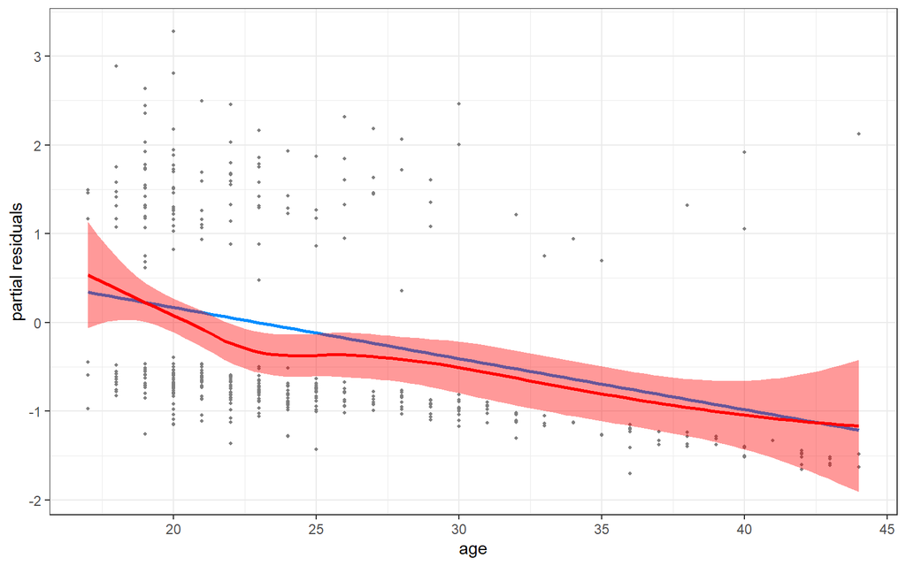

```r
visreg(recid.ph, "age", xlab = "age", ylab = "partial residuals", gg = TRUE,
       band = FALSE) +
  geom_smooth(col = "red", fill = "red", level = 0.985) + theme_bw()
```

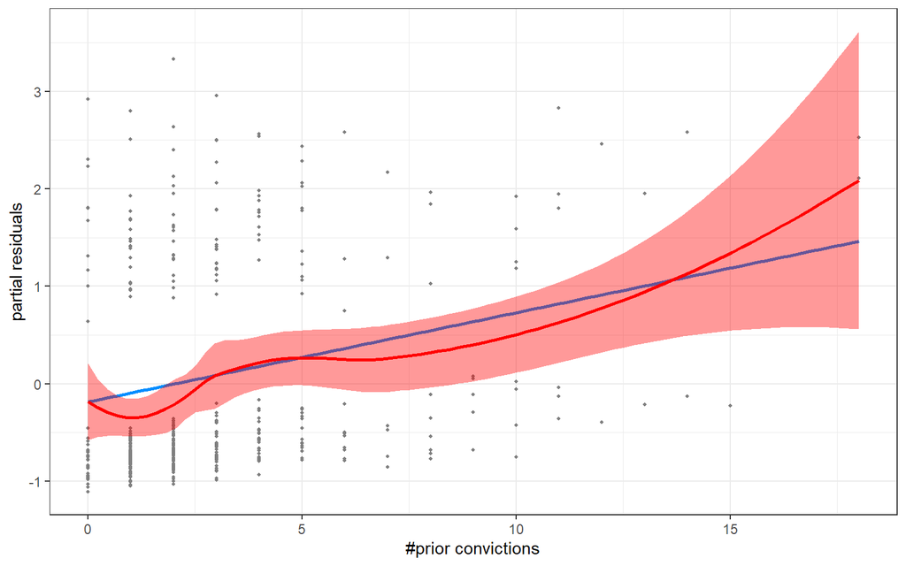

```r
visreg(recid.ph, "prio", xlab = "#prior convictions", ylab = "partial residuals",
       gg = TRUE, band = FALSE) +
  geom_smooth(col = "red", fill = "red", level = 0.985) + theme_bw()
```

Let’s talk about the above plots. R fits a spline through the residuals to try and pick up the underlying pattern in the residuals. It then puts a line that would represent the linear relationship of the variables in our model. If linearity holds we should see the confidence interval completely cover the straight line. We can see some slight departures from this pattern, but overall it looks like it captures the line in both plots.

### Test for Proportional Hazards

The other major assumption in the proportional hazards model is in the name - proportional hazards. Remember, proportional hazards implies our estimation is no longer time dependent as there is a constant proportion on hazards. This is a rather strong assumption for all of our variables.

Each software has slightly different approaches that are available to test this assumption. Let’s see how each of our softwares performs this!

#### SAS

There are a couple of different ways to test for proportional hazards in SAS. The first way uses martingale residuals. SAS creates a random walk time series for your residuals across tenure since there should be no pattern to the residuals if they meet the proportional hazards assumption. If your model produces residuals with more than expected pattern, then you have a problem with the assumption.

Again, we can test this assumption using options in PROC PHREG. Just like with our linearity assumption, we will use the `assess` statement. Here, we will also specify the `ph` option so that the proportional hazard assumption is retested. The `resample` option specifies that we want ot use simulation to perform this test.

Notice how we are testing this on all the variables in the original data. This is due to the fact that *if* the proportional hazard assumption isn’t met, we can not trust the p-values from the hypothesis tests. Ideally, we test this assumption as one of the **first steps** in building a Cox regression model.

```
ods html select ProportionalHazardsSupTest;
proc phreg data=Survival.Recid;
    model week*arrest(0) = fin age race wexp mar paro prio / ties=efron;
    assess ph / resample;
run;
```

| Supremum Test for Proportionals Hazards Assumption Variable | Supremum Test for Proportionals Hazards Assumption Maximum Absolute Value | Supremum Test for Proportionals Hazards Assumption Replications | Supremum Test for Proportionals Hazards Assumption Seed | Supremum Test for Proportionals Hazards Assumption Pr > MaxAbsVal |
| --- | --- | --- | --- | --- |
| fin | 0.5408 | 1000 | 157887369 | 0.8480 |
| age | 1.8192 | 1000 | 157887369 | 0.0210 |
| race | 0.9435 | 1000 | 157887369 | 0.2220 |
| wexp | 1.3008 | 1000 | 157887369 | 0.0980 |
| mar | 0.9349 | 1000 | 157887369 | 0.2480 |
| paro | 0.5383 | 1000 | 157887369 | 0.8480 |
| prio | 0.6104 | 1000 | 157887369 | 0.7360 |

SAS also uses Schoenfeld residuals to investigate the relationship of variables across time since these residuals are calculated on a variable by variable basis. We either plot these residuals against functions of time **or** test the correlation between these residuals and functions of time with the later being the most popular. Common examples of time functions are the linear function $t$ and the natural log of time $\log(t)$. If this correlation is statistically different than zero, we say the assumption of proportional hazards is **not** met. We can perform all three of these comparisons using the `zph` option. Inside the `zph` option are sub-options. The `global` sub-option calculates the global version of the test. The `transform =` option tells SAS which transformation you would like to test - `identity` for linear time, and `log` for natural log of time.

```
ods html select zphTest;
proc phreg data = Survival.Recid zph(global transform=identity);
    model week*arrest(0) = fin age race wexp mar paro prio / ties = efron;
run;

ods html select zphTest;
proc phreg data = Survival.Recid zph(global transform=log);
    model week*arrest(0) = fin age race wexp mar paro prio / ties = efron;
run;
```

| zph Tests for Nonproportional Hazards Transform | zph Tests for Nonproportional Hazards Predictor Variable | zph Tests for Nonproportional Hazards Correlation | zph Tests for Nonproportional Hazards ChiSquare | zph Tests for Nonproportional Hazards Pr > ChiSquare | zph Tests for Nonproportional Hazards t Value | zph Tests for Nonproportional Hazards Pr > \|t\| |
| --- | --- | --- | --- | --- | --- | --- |
| IDENTITY | fin | 0.0216 | 0.0562 | 0.8127 | 0.23 | 0.8195 |
| IDENTITY | age | -0.2736 | 12.0607 | 0.0005 | -3.01 | 0.0032 |
| IDENTITY | race | -0.1150 | 1.4860 | 0.2228 | -1.22 | 0.2232 |
| IDENTITY | wexp | 0.2264 | 6.9347 | 0.0085 | 2.46 | 0.0154 |
| IDENTITY | mar | 0.0765 | 0.7543 | 0.3851 | 0.81 | 0.4187 |
| IDENTITY | paro | -0.0321 | 0.1220 | 0.7269 | -0.34 | 0.7345 |
| IDENTITY | prio | -0.00937 | 0.0108 | 0.9171 | -0.10 | 0.9212 |
| IDENTITY | *Global* | . | 18.1552 | 0.0113 | . | . |

| zph Tests for Nonproportional Hazards Transform | zph Tests for Nonproportional Hazards Predictor Variable | zph Tests for Nonproportional Hazards Correlation | zph Tests for Nonproportional Hazards ChiSquare | zph Tests for Nonproportional Hazards Pr > ChiSquare | zph Tests for Nonproportional Hazards t Value | zph Tests for Nonproportional Hazards Pr > \|t\| |
| --- | --- | --- | --- | --- | --- | --- |
| LOG | fin | 0.0639 | 0.4913 | 0.4833 | 0.68 | 0.4993 |
| LOG | age | -0.2848 | 13.0732 | 0.0003 | -3.14 | 0.0021 |
| LOG | race | -0.0958 | 1.0311 | 0.3099 | -1.02 | 0.3108 |
| LOG | wexp | 0.2024 | 5.5397 | 0.0186 | 2.19 | 0.0308 |
| LOG | mar | 0.0893 | 1.0291 | 0.3104 | 0.95 | 0.3446 |
| LOG | paro | 0.00942 | 0.0105 | 0.9184 | 0.10 | 0.9207 |
| LOG | prio | 0.0558 | 0.3843 | 0.5353 | 0.59 | 0.5555 |
| LOG | *Global* | . | 17.6777 | 0.0135 | . | . |

Let’s examine the tables above. Each table provides both a global (final line of each table) and variable by variable statistical test. We want to find the significant p-values across our tables. The only two variables that appear significant in at least one table are *age* and *wexp*. Next, we find the lowest p-value for each of those variables. The *wexp* variable has the lowest p-value with the identity transformation. The *age* variable has the lowest p-value with the natural log transformation.

These results will be used in the last sections of the notes on non-proportional hazards models. The next sections would be the approach if all the assumptions are met *or* after you have corrected for the assumptions that were not met.

#### R

Unlike SAS, R only uses Schoenfeld residuals to investigate the relationship of variables across time and test for the proportional hazards assumption. We either plot these residuals against functions of time **or** test the correlation between these residuals and functions of time with the later being the most popular. Common examples of time functions are the linear function $t$ and the natural log of time $\log(t)$. If this correlation is statistically different than zero, we say the assumption of proportional hazards is **not** met. We can perform all three of these comparisons using the `cox.zph` function on our model object. Inside the `transform =` option tells R which transformation you would like to test - `identity` for linear time, and `log` for natural log of time.

```r
recid.ph <- coxph(Surv(week, arrest == 1) ~ fin + age + race + wexp + mar +paro + prio, data = recid)

recid.ph.zph <- cox.zph(recid.ph, transform = "identity")
recid.ph.zph
```

```
          chisq df     p
fin     0.00895  1 0.925
age     6.61594  1 0.010
race    2.14443  1 0.143
wexp    3.87676  1 0.049
mar     1.03135  1 0.310
paro    0.02818  1 0.867
prio    0.42480  1 0.515
GLOBAL 18.18269  7 0.011
```

```r
recid.ph.zph <- cox.zph(recid.ph, transform = "log")
recid.ph.zph
```

```
         chisq df      p
fin     0.1376  1 0.7107
age     8.2315  1 0.0041
race    1.6171  1 0.2035
wexp    2.0859  1 0.1487
mar     1.1260  1 0.2886
paro    0.2192  1 0.6396
prio    0.0135  1 0.9076
GLOBAL 17.6616  7 0.0136
```

Let’s examine the tables above. Each table provides both a global (final line of each table) and variable by variable statistical test. We want to find the significant p-values across our tables. The only variable that appears significant in at least one table is *age* (at a significance level of 0.015). Next, we find the lowest p-value for this variable. The *age* variable has the lowest p-value with the natural log transformation.

These results will be used in the last sections of the notes on non-proportional hazards models. The next sections would be the approach if all the assumptions are met *or* after you have corrected for the assumptions that were not met.

## Automatic Selection Techniques

With the distributional assumptions out of the way thanks to the above partial maximum likelihood approach, we can jump right into variable selection. Stepwise selection techniques involve the three common methods:

1. Forward Selection
2. Backward Selection
3. Stepwise Selection

These techniques add or remove (depending the technique) one variable at a time from your regression model to try and “improve” the model. There are a variety of different selection criteria to use to add or remove variables from a model. The softwares we explore use different approaches so let’s examine each one!

### SAS

PROC PHREG uses significance levels and p-values for adding or removing variables from the stepwise selection techniques. Although p-values are falling out of popularity, it is primarily because people often use the 0.05 significance level without any regards to sample size. Although 0.05 is a good significance level for a sample size around 50, this level should be adjusted based on sample size. The mathematical details are not covered here, but it can be shown that the BIC criterion for adding or removing variables with stepwise selection (which is becoming very popular) is the same thing as using p-values in likelihood ratio tests. However, the significance level changes depending on sample size due to the BIC equation, which is exactly what is recommended for any selection techniques using p-values.

#### Stepwise Selection

Here we will work through stepwise selection. In stepwise selection, the initial model is empty (contains no variables, only the intercept). Each variable is then tried to see if it is significant based on p-value and a specified significance level. The most significant variable (if any) is then added to the model. Next, all variables in the model (here only one) are tested to see if they are still significant. If not, they are dropped. If so, then the remaining variables are again tested and the next most significant variable is added to the model. This process repeats until either no more significant variables are available to add or the same variable keeps being added and then removed from the model.

PROC PHREG uses the `selection = stepwise` option to perform this technique. Notice also the `slentry =` and `slstay =` options where we specify the significance to both enter and stay in the model respectively. Here we chose 0.015 based on our sample size.

```
ods html select ModelBuildingSummary ParameterEstimates;
proc phreg data=Survival.Recid;
    model week*arrest(0) = fin age race wexp mar paro prio / ties=efron selection=stepwise
                                                           slentry=0.015 slstay=0.015;
run;
```

| Analysis of Maximum Likelihood Estimates Parameter | Analysis of Maximum Likelihood Estimates DF | Analysis of Maximum Likelihood Estimates Parameter Estimate | Analysis of Maximum Likelihood Estimates Standard Error | Analysis of Maximum Likelihood Estimates Chi-Square | Analysis of Maximum Likelihood Estimates Pr > ChiSq | Analysis of Maximum Likelihood Estimates Hazard Ratio |
| --- | --- | --- | --- | --- | --- | --- |
| age | 1 | -0.06933 | 0.02079 | 11.1177 | 0.0009 | 0.933 |
| prio | 1 | 0.09467 | 0.02710 | 12.2006 | 0.0005 | 1.099 |

[output not shown]

The model building summary is shown to have only added two variables - *prio* and *age*. This may be different across different stepwise techniques.

#### Backward Selection

Here we will work through backward selection. In backward selection, the initial model is full (contains all variables, including the intercept). Each variable is then tried to see if it is significant based on p-value and a specified significance level. The least significant variable (if any) is then dropped from the model. Then the remaining variables are again tested and the next least significant variable is dropped from the model. This process repeats until no more insignificant variables are available to drop.

PROC PHREG uses the `selection = backward` option to perform this technique. Notice also the `slstay =` option where we specify the significance to stay in the model. Here we chose 0.015 based on our sample size.

```
ods html select ModelBuildingSummary ParameterEstimates;
proc phreg data=Survival.Recid;
    model week*arrest(0) = fin age race wexp mar paro prio / ties=efron selection=backward
                                                           slstay=0.015;
run;
```

| Analysis of Maximum Likelihood Estimates Parameter | Analysis of Maximum Likelihood Estimates DF | Analysis of Maximum Likelihood Estimates Parameter Estimate | Analysis of Maximum Likelihood Estimates Standard Error | Analysis of Maximum Likelihood Estimates Chi-Square | Analysis of Maximum Likelihood Estimates Pr > ChiSq | Analysis of Maximum Likelihood Estimates Hazard Ratio |
| --- | --- | --- | --- | --- | --- | --- |
| age | 1 | -0.06933 | 0.02079 | 11.1177 | 0.0009 | 0.933 |
| prio | 1 | 0.09467 | 0.02710 | 12.2006 | 0.0005 | 1.099 |

| Summary of Backward Elimination Step | Summary of Backward Elimination Effect Removed | Summary of Backward Elimination DF | Summary of Backward Elimination Number In | Summary of Backward Elimination Wald Chi-Square | Summary of Backward Elimination Pr > ChiSq |
| --- | --- | --- | --- | --- | --- |
| 1 | paro | 1 | 6 | 0.1879 | 0.6646 |
| 2 | wexp | 1 | 5 | 0.5221 | 0.4699 |
| 3 | race | 1 | 4 | 1.0584 | 0.3036 |
| 4 | mar | 1 | 3 | 2.0453 | 0.1527 |
| 5 | fin | 1 | 2 | 3.3257 | 0.0682 |

The model building summary is shown to have deleted all but two variables - *prio* and *age*. This may be different across different stepwise techniques.

#### Forward Selection

Here we will work through forward selection. In forward selection, the initial model is empty (contains no variables, only the intercept). Each variable is then tried to see if it is significant based on p-value and a specified significance level. The most significant variable (if any) is then added to the model. Then the remaining variables are again tested and the next most significant variable is added to the model. This process repeats until no more significant variables are available to add.

```
ods html select ModelBuildingSummary ParameterEstimates;
proc phreg data=Survival.Recid;
    model week*arrest(0) = fin age race wexp mar paro prio / ties=efron selection=forward
                                                           slentry=0.015;
run;
```

| Analysis of Maximum Likelihood Estimates Parameter | Analysis of Maximum Likelihood Estimates DF | Analysis of Maximum Likelihood Estimates Parameter Estimate | Analysis of Maximum Likelihood Estimates Standard Error | Analysis of Maximum Likelihood Estimates Chi-Square | Analysis of Maximum Likelihood Estimates Pr > ChiSq | Analysis of Maximum Likelihood Estimates Hazard Ratio |
| --- | --- | --- | --- | --- | --- | --- |
| age | 1 | -0.06933 | 0.02079 | 11.1177 | 0.0009 | 0.933 |
| prio | 1 | 0.09467 | 0.02710 | 12.2006 | 0.0005 | 1.099 |

| Summary of Forward Selection Step | Summary of Forward Selection Effect Entered | Summary of Forward Selection DF | Summary of Forward Selection Number In | Summary of Forward Selection Score Chi-Square | Summary of Forward Selection Pr > ChiSq |
| --- | --- | --- | --- | --- | --- |
| 1 | prio | 1 | 1 | 14.6406 | 0.0001 |
| 2 | age | 1 | 2 | 11.4593 | 0.0007 |

### R

R’s `step` function uses either AIC or BIC adding or removing variables from the stepwise selection techniques. Although p-values are falling out of popularity, it is primarily because people often use the 0.05 significance level without any regards to sample size. Although 0.05 is a good significance level for a sample size around 50, this level should be adjusted based on sample size. The mathematical details are not covered here, but it can be shown that the BIC criterion for adding or removing variables with stepwise selection (which is becoming very popular) is the same thing as using p-values in likelihood ratio tests. However, the significance level changes depending on sample size due to the BIC equation, which is exactly what is recommended for any selection techniques using p-values.

#### Stepwise Selection

Here we will work through stepwise selection. In stepwise selection, the initial model is empty (contains no variables, only the intercept). Each variable is then tried to see if it is significant based on p-value and a specified significance level. The most significant variable (if any) is then added to the model. Next, all variables in the model (here only one) are tested to see if they are still significant. If not, they are dropped. If so, then the remaining variables are again tested and the next most significant variable is added to the model. This process repeats until either no more significant variables are available to add or the same variable keeps being added and then removed from the model.

In R we must specify two models - the empty and full models - to step between. Notice the full model contains all the variables, while the empty model contains only the intercept (signified by `~ 1` in the formula). We then use the `step` function where we start at the empty model. The `scope` option tells R the lower (`lower =`) and upper (`upper =`) model to step between. The `direction = "both"` option tells R to use stepwise selection.

```r
full.model <- coxph(Surv(week, arrest == 1) ~ fin + age + race + wexp + mar +paro + prio,
                    data = recid)

empty.model <- coxph(Surv(week, arrest == 1) ~ 1, data = recid)

step.model <- step(empty.model,
                   scope = list(lower=formula(empty.model),
                                upper=formula(full.model)),
                   direction = "both", trace = 0)
summary(step.model)
```

```
Call:
coxph(formula = Surv(week, arrest == 1) ~ age + prio + fin +
    mar, data = recid)

  n= 432, number of events= 114

         coef exp(coef) se(coef)      z Pr(>|z|)
age  -0.06042   0.94137  0.02085 -2.897  0.00376 **
prio  0.09751   1.10243  0.02722  3.583  0.00034 ***
fin  -0.36020   0.69753  0.19049 -1.891  0.05864 .
mar  -0.53312   0.58677  0.37276 -1.430  0.15266
---
Signif. codes:  0 '***' 0.001 '**' 0.01 '*' 0.05 '.' 0.1 ' ' 1

     exp(coef) exp(-coef) lower .95 upper .95
age     0.9414     1.0623    0.9037    0.9806
prio    1.1024     0.9071    1.0452    1.1628
fin     0.6975     1.4336    0.4802    1.0132
mar     0.5868     1.7042    0.2826    1.2183

Concordance= 0.633  (se = 0.027 )
Likelihood ratio test= 31.41  on 4 df,   p=3e-06
Wald test            = 29.98  on 4 df,   p=5e-06
Score (logrank) test = 31.25  on 4 df,   p=3e-06
```

The model building summary is shown to have added four variables - *age*, *prio*, *fin*, and *mar* - based on lowest AIC. This may be different across different stepwise techniques. To adjust to the BIC instead of AIC, you can use the `k = log(dim(recid)[1])` option in the step function. This will make the penalty term equal to the natural log of the sample size (BIC) instead of 2 (AIC).

#### Backward Selection

Here we will work through backward selection. In backward selection, the initial model is full (contains all variables, including the intercept). Each variable is then tried to see if it is significant based on p-value and a specified significance level. The least significant variable (if any) is then dropped from the model. Then the remaining variables are again tested and the next least significant variable is dropped from the model. This process repeats until no more insignificant variables are available to drop.

In R we must specify one model - the full model - to step backward from. Notice the full model contains all the variables. We then use the `step` function where we start at the full model. The `direction = "backward"` option tells R to use backward selection.

```r
full.model <- coxph(Surv(week, arrest == 1) ~ fin + age + race + wexp + mar +paro + prio,
                    data = recid)

back.model <- step(full.model, direction = "backward", trace = 0)
summary(back.model)
```

```
Call:
coxph(formula = Surv(week, arrest == 1) ~ fin + age + mar + prio,
    data = recid)

  n= 432, number of events= 114

         coef exp(coef) se(coef)      z Pr(>|z|)
fin  -0.36020   0.69753  0.19049 -1.891  0.05864 .
age  -0.06042   0.94137  0.02085 -2.897  0.00376 **
mar  -0.53312   0.58677  0.37276 -1.430  0.15266
prio  0.09751   1.10243  0.02722  3.583  0.00034 ***
---
Signif. codes:  0 '***' 0.001 '**' 0.01 '*' 0.05 '.' 0.1 ' ' 1

     exp(coef) exp(-coef) lower .95 upper .95
fin     0.6975     1.4336    0.4802    1.0132
age     0.9414     1.0623    0.9037    0.9806
mar     0.5868     1.7042    0.2826    1.2183
prio    1.1024     0.9071    1.0452    1.1628

Concordance= 0.633  (se = 0.027 )
Likelihood ratio test= 31.41  on 4 df,   p=3e-06
Wald test            = 29.98  on 4 df,   p=5e-06
Score (logrank) test = 31.25  on 4 df,   p=3e-06
```

The model building summary is shown to have deleted all but four variables - *age*, *prio*, *fin*, and *mar* - based on lowest AIC. This may be different across different stepwise techniques. To adjust to the BIC instead of AIC, you can use the `k = log(dim(recid)[1])` option in the step function. This will make the penalty term equal to the natural log of the sample size (BIC) instead of 2 (AIC).

#### Forward Selection

Here we will work through forward selection. In forward selection, the initial model is empty (contains no variables, only the intercept). Each variable is then tried to see if it is significant based on p-value and a specified significance level. The most significant variable (if any) is then added to the model. Then the remaining variables are again tested and the next most significant variable is added to the model. This process repeats until no more significant variables are available to add.

In R we must specify two models to step between. We then use the `step` function where we start at the empty model. The `scope` option tells R the lower (`lower =`) and upper (`upper =`) model to step between. The `direction = "forward"` option tells R to use stepwise selection.

```r
full.model <- coxph(Surv(week, arrest == 1) ~ fin + age + race + wexp + mar +paro + prio,
                    data = recid)

empty.model <- coxph(Surv(week, arrest == 1) ~ 1, data = recid)

for.model <- step(empty.model,
                  scope = list(lower=formula(empty.model),
                               upper=formula(full.model)),
                  direction = "forward", trace = 0)
summary(for.model)
```

```
Call:
coxph(formula = Surv(week, arrest == 1) ~ age + prio + fin +
    mar, data = recid)

  n= 432, number of events= 114

         coef exp(coef) se(coef)      z Pr(>|z|)
age  -0.06042   0.94137  0.02085 -2.897  0.00376 **
prio  0.09751   1.10243  0.02722  3.583  0.00034 ***
fin  -0.36020   0.69753  0.19049 -1.891  0.05864 .
mar  -0.53312   0.58677  0.37276 -1.430  0.15266
---
Signif. codes:  0 '***' 0.001 '**' 0.01 '*' 0.05 '.' 0.1 ' ' 1

     exp(coef) exp(-coef) lower .95 upper .95
age     0.9414     1.0623    0.9037    0.9806
prio    1.1024     0.9071    1.0452    1.1628
fin     0.6975     1.4336    0.4802    1.0132
mar     0.5868     1.7042    0.2826    1.2183

Concordance= 0.633  (se = 0.027 )
Likelihood ratio test= 31.41  on 4 df,   p=3e-06
Wald test            = 29.98  on 4 df,   p=5e-06
Score (logrank) test = 31.25  on 4 df,   p=3e-06
```

The model building summary is shown to have added four variables - *age*, *prio*, *fin*, and *mar* - based on lowest AIC. This may be different across different stepwise techniques. To adjust to the BIC instead of AIC, you can use the `k = log(dim(recid)[1])` option in the step function. This will make the penalty term equal to the natural log of the sample size (BIC) instead of 2 (AIC).

## Predictions

There are some forms of predictions that we can get for the Cox regression model, even if they aren’t as well defined as the AFT mdoel. Once we have obtained parameter estimates from the partial likelihood estimation, we can plug in into the full likelihood and non-parametrically estimate the remaining piece of the likelihood. It is essentially combining the concepts of partial MLE and Kaplan-Meier. This helps us estimate the survival curves for predefined combinations of the predictor variables.

Let’s see how to do this in each of our softwares!

### SAS

In SAS we can “score” these new observations right in our PROC PHREG procedure. First, let’s create a couple of observations of interest using the DATA step. Here we define two new observations with slightly different inputs. In PROC PHREG we use the `baseline` statement along with the `covariates =` option to define the data set that needs to be scored. The `out =` option defines the name of the data set we will save our results to.

```
data ref;
    input fin age race wexp mar paro prio;
datalines;
1 30 0 1 0 0 0
0 30 0 0 0 0 4
;
run;

ods html select SurvivalPlot;
proc phreg data=Survival.Recid plots(overlay)=survival;
    model week*arrest(0) = fin age race wexp mar paro prio / ties = efron risklimits=pl;
    baseline covariates=ref out=refs;
run;
```

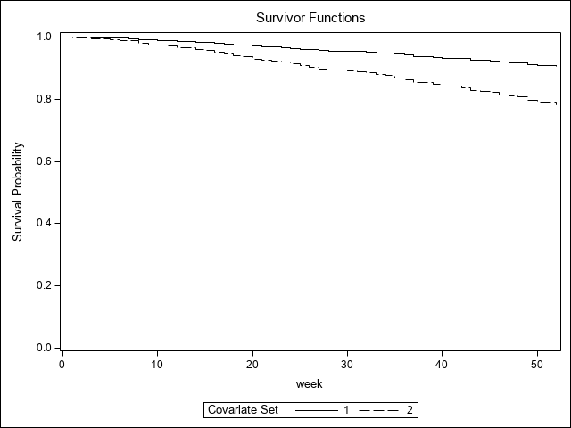

From the output above we can see the two survival curves for the observations we defined in our data set. With these survival curves, we can estimate quantile survival times, such as the median.

### R

In R we can “score” these new observations with our `ggsurvplot` function. First, let’s create a couple of observations of interest using the `data.frame` function. Here we define two new observations with slightly different inputs. In `ggruvplot` we use the `survfit` function to combine our model object with our new data. The `data =` option also defines the data set we are looking to score. The rest of the options are there for appearance.

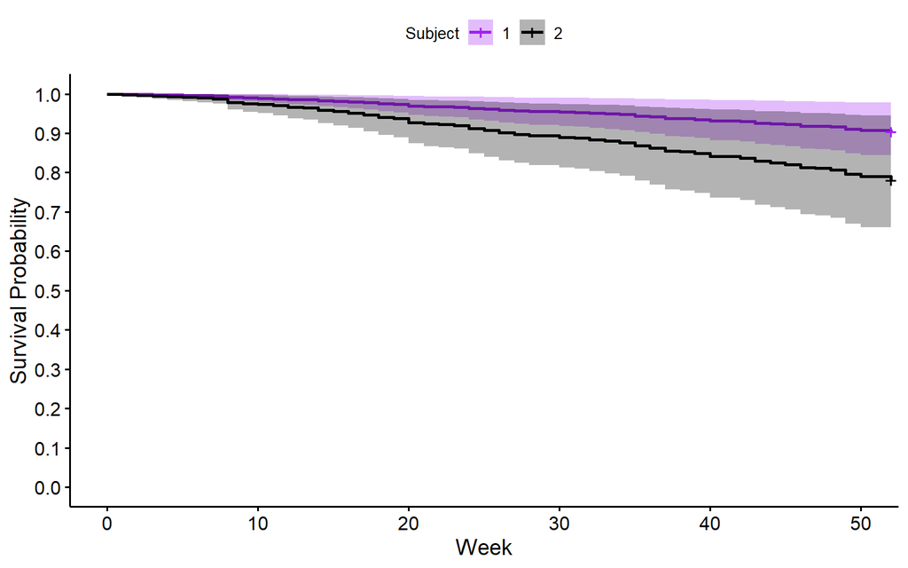

```r
newdata <- data.frame(fin = c(1, 0), age = 30, race = 0, wexp = c(1, 0),
                      mar = 0, paro = 0, prio = c(0, 4))

ggsurvplot(survfit(recid.ph, newdata), data = newdata, break.y.by = 0.1,
           palette = c("purple", "black"), ylab = "Survival Probability",
           xlab = "Week", legend.labs = c("1", "2"), legend.title = "Subject")
```

From the output above we can see the two survival curves for the observations we defined in our data set. With these survival curves, we can estimate quantile survival times, such as the median.

## Model Assessment

It is always of interest to know how “well” our model did. Due to censoring as well as Cox regression making relative predictions, model evaluation is not easy/intuitive to evaluate.

Concordance is a popular method to assess model performance. The classical definition for concordance is that for all possible event and non-event pairs, we want to assign the higher predicted value to the subject that had the event. There is a different spin on this definition for survival analysis - we assign a higher “risk” to the subject that had the event **first**. Essentially, we want to know how well the model ranks who will have the event sooner. What is “risk” in this context? It is the linear piece to our model: $\hat{\beta}_1 x_{i,1} + \cdots + \hat{\beta}_k x_{i,k}$. Let’s compare two individuals:

1. Person 1 - event at time 3, and $\hat{\beta}_1 x_{i,1} + \cdots + \hat{\beta}_k x_{i,k} = 1.5$
2. Person 2 - event (or censored) at time 7, and $\hat{\beta}_1 x_{i,1} + \cdots + \hat{\beta}_k x_{i,k} = 0.3$

The above pair is concordant because the person with the higher “risk” had the event first. If both people have the same event time or censoring time, then the pair is **incomparable** and we do not count it. Censoring can lead to some hard comparisons though. Let’s look at the following two individuals:

1. Person 1 - **censored** at time 3, and $\hat{\beta}_1 x_{i,1} + \cdots + \hat{\beta}_k x_{i,k} = 1.5$
2. Person 2 - event (or censored) at time 7, and $\hat{\beta}_1 x_{i,1} + \cdots + \hat{\beta}_k x_{i,k} = 0.3$

This pair is unknown - called **indeterminate** since there is no way to know which person had the event first. If both people have the same predicted “risk” then the pair is considered a **tie** and counted as 0.5.

Let’s see how to do this in each of our softwares!

### SAS

SAS still uses PROC PHREG to get the main model output. All we have to do is add the `concordance` option to get the concordance calculations.

```
ods html select ParameterEstimates Concordance;
proc phreg data=Survival.Recid concordance;
    model week*arrest(0) = fin age prio / ties=efron risklimits=pl;
run;
```

| Analysis of Maximum Likelihood Estimates Parameter | Analysis of Maximum Likelihood Estimates DF | Analysis of Maximum Likelihood Estimates Parameter Estimate | Analysis of Maximum Likelihood Estimates Standard Error | Analysis of Maximum Likelihood Estimates Chi-Square | Analysis of Maximum Likelihood Estimates Pr > ChiSq | Analysis of Maximum Likelihood Estimates Hazard Ratio | Analysis of Maximum Likelihood Estimates 95% Hazard Ratio Profile Likelihood Confidence Limits | Analysis of Maximum Likelihood Estimates 95% Hazard Ratio Profile Likelihood Confidence Limits |
| --- | --- | --- | --- | --- | --- | --- | --- | --- |
| fin | 1 | -0.34694 | 0.19025 | 3.3257 | 0.0682 | 0.707 | 0.485 | 1.024 |
| age | 1 | -0.06710 | 0.02085 | 10.3565 | 0.0013 | 0.935 | 0.896 | 0.972 |
| prio | 1 | 0.09691 | 0.02725 | 12.6458 | 0.0004 | 1.102 | 1.042 | 1.159 |

| Harrell's Concordance Statistic Source | Harrell's Concordance Statistic Estimate | Harrell's Concordance Statistic Comparable Pairs Concordance | Harrell's Concordance Statistic Comparable Pairs Discordance | Harrell's Concordance Statistic Comparable Pairs Tied in Predictor | Harrell's Concordance Statistic Comparable Pairs Tied in Time |
| --- | --- | --- | --- | --- | --- |
| Model | 0.6302 | 26736 | 15651 | 195 | 111 |

SAS provides the total count of pairs and their breakdown by type. It also provides the proportion of these pairs that are concordant as 0.6302. This is the number we compare across models. Just as with other model metrics, there is no number for concordance that is “good” but rather one model can be better than another. That is why it is good to build multiple models to compare.

### R

In R we just have to use the `concordance` function on the propotional hazards model object to obtain the concordance calculations.

```r
recid.ph <- coxph(Surv(week, arrest == 1) ~ fin + age + prio, data = recid)

concordance(recid.ph)
```

```
Call:
concordance.coxph(object = recid.ph)

n= 432
Concordance= 0.6302 se= 0.02729
concordant discordant     tied.x     tied.y    tied.xy
     26736      15651        195        111          0
```

R provides the total count of pairs and their breakdown by type. It also provides the proportion of these pairs that are concordant as 0.6302. This is the number we compare across models. Just as with other model metrics, there is no number for concordance that is “good” but rather one model can be better than another. That is why it is good to build multiple models to compare.

## Non-Proportional Hazards Models

What if the assumption for proportional hazards doesn’t hold? What if our variables are changing across time? Both of these situations lead to non-proportional hazards models. Two common reasons you don’t have proportional hazards are the following:

1. Time-Dependent Coefficients
2. Time-Dependent Variables

### Time Dependent Coefficients

Models up until this point have assumed that predictors have a constant effect, $\beta$, on the target variable. In proportional hazards models, we assume effects are **constant over time**, so that the hazard reatio is independent of time. What if this didn’t hold true and the effect of a predictor variable could change across time? For example, what if *age* didn’t have a constant effect across time? These effects, now $\beta(t)$, are called **time-varying coefficients** or time-dependent coefficients. Now at least one of the variable’s coefficients in the model becomes the following:

$$\log h(t) = \log h_0 (t) + \beta_1 x_{i,1} + \cdots + \beta_j (t) x_{i,j} + \cdots + \beta_k x_{i,k}$$

These time-varying coefficients are functions of time. For example, it could be a linear function of time:

$$\beta_j (t) = \beta_j + b\times t$$

If $b = 0$, then the effect doesn’t depend on time (proportional hazards assumption satisfied). If $b \ne 0$, then the effect does depend on time (proportional hazards assumption failed). As mentioned in the Diagnostics section of the notes, Schoenfeld residuals are best used for investigating relationships with time for predictor variables. Earlier we saw that the *age* variable seemed to break the proportional hazards assumption and that it was correlated the highest with the $\log (t)$ transformation. That means that our *age* variable has a coefficient like the following:

$$\beta_{age} (t) = \beta_{age} + b\times \log(week)$$

*CAREFUL*! This is *NOT* like creating a standard interaction with time for your predictor variable. The interaction must be constructed in a way that updates at each time point. Luckily, our softwares can easily do this for us.

Let’s see how our softwares can account for this!

#### SAS

PROC PHREG can build these time-varying coefficients for you if you specify the time-varying nature of them. Notice in the `model` statement below we have two new variables *agelogweek* and *wexpweek*. These two variables have actually been created in the statements below the `model` statement. Here we create `agelogweek = age*log(week)`. This tells SAS that we want the coefficient on the *age* variable to be time-varying with $\log(t)$ to be the function of time. The *wexp* variable is given the identity function as well.

```
ods html select ParameterEstimates;
proc phreg data=Survival.Recid;
    model week*arrest(0) = fin age race wexp mar paro prio agelogweek wexpweek / ties=efron;
    agelogweek = age*log(week);
    wexpweek = wexp*week;
run;
```

| Analysis of Maximum Likelihood Estimates Parameter | Analysis of Maximum Likelihood Estimates DF | Analysis of Maximum Likelihood Estimates Parameter Estimate | Analysis of Maximum Likelihood Estimates Standard Error | Analysis of Maximum Likelihood Estimates Chi-Square | Analysis of Maximum Likelihood Estimates Pr > ChiSq | Analysis of Maximum Likelihood Estimates Hazard Ratio |
| --- | --- | --- | --- | --- | --- | --- |
| fin | 1 | -0.38015 | 0.19108 | 3.9579 | 0.0467 | 0.684 |
| age | 1 | 0.17251 | 0.06609 | 6.8136 | 0.0090 | 1.188 |
| race | 1 | 0.29513 | 0.30836 | 0.9161 | 0.3385 | 1.343 |
| wexp | 1 | -1.25060 | 0.46745 | 7.1576 | 0.0075 | 0.286 |
| mar | 1 | -0.40772 | 0.38225 | 1.1377 | 0.2861 | 0.665 |
| paro | 1 | -0.09846 | 0.19561 | 0.2534 | 0.6147 | 0.906 |
| prio | 1 | 0.09074 | 0.02866 | 10.0276 | 0.0015 | 1.095 |
| agelogweek | 1 | -0.07652 | 0.02220 | 11.8778 | 0.0006 | 0.926 |
| wexpweek | 1 | 0.03864 | 0.01411 | 7.5034 | 0.0062 | 1.039 |

In the above output, both of these variables appear significant. Let’s examine the *age* variable further. The coefficient on *age* of 0.173 along with the coefficient on *agelogweek* of -0.077 make up the whole effect of *age*:

$$\beta_{age} (t) = 0.173 - 0.077\times \log(week)$$

#### R

R can build these time-varying coefficients for you if you specify the time-varying nature of them in the `coxph` function. Notice in the model formula below we have one new variable *tt(age)*. This variable has actually been created in the statements after the model formula. Here we create our own `tt` function defined as `tt = function(x, time, ...){xlog(time)}`. This tells R that we want the coefficient on the *age* variable to be time-varying with $\log(t)$ to be the function of time.

```r
recid.ph.tdc <- coxph(Surv(week, arrest == 1) ~ fin + race + wexp + mar + paro + age + tt(age), data = recid,
                 tt = function(x, time, ...){x*log(time)})
summary(recid.ph.tdc)
```

```
Call:
coxph(formula = Surv(week, arrest == 1) ~ fin + race + wexp +
    mar + paro + age + tt(age), data = recid, tt = function(x,
    time, ...) {
    x * log(time)
})

  n= 432, number of events= 114

            coef exp(coef) se(coef)      z Pr(>|z|)
fin     -0.36196   0.69631  0.19073 -1.898  0.05773 .
race     0.26275   1.30050  0.30677  0.857  0.39171
wexp    -0.28437   0.75249  0.20529 -1.385  0.16598
mar     -0.36769   0.69233  0.38055 -0.966  0.33394
paro    -0.16886   0.84462  0.19353 -0.873  0.38290
age      0.11703   1.12415  0.06521  1.795  0.07270 .
tt(age) -0.05777   0.94387  0.02177 -2.653  0.00798 **
---
Signif. codes:  0 '***' 0.001 '**' 0.01 '*' 0.05 '.' 0.1 ' ' 1

        exp(coef) exp(-coef) lower .95 upper .95
fin        0.6963     1.4361    0.4791     1.012
race       1.3005     0.7689    0.7128     2.373
wexp       0.7525     1.3289    0.5032     1.125
mar        0.6923     1.4444    0.3284     1.460
paro       0.8446     1.1840    0.5780     1.234
age        1.1242     0.8896    0.9893     1.277
tt(age)    0.9439     1.0595    0.9044     0.985

Concordance= 0.638  (se = 0.025 )
Likelihood ratio test= 30.56  on 7 df,   p=7e-05
Wald test            = 25.43  on 7 df,   p=6e-04
Score (logrank) test = 26.55  on 7 df,   p=4e-04
```

In the above output, this variable appear significant. Let’s examine the *age* variable further. The coefficient on *age* of 0.117 along with the coefficient on *tt(age)* of -0.058 make up the whole effect of *age*:

$$\beta_{age} (t) = 0.117 - 0.058\times \log(week)$$

### Time Dependent Variables

Similar to time-dependent coefficients, **time-dependent variables** have the actual value of the predictor variable (rather than its effect) change over time. For example, age at entry and race would be independent variable examples since they don’t change. However, variables like employment status and blood pressure might change over a survival analysis study. Now at least one of the variables in the model becomes the following:

$$\log h(t) = \log h_0 (t) + \beta_1 x_{i,1} + \cdots + \beta_j x_{i,j}(t) + \cdots + \beta_k x_{i,k}$$

In our prisoner recidivism data, we have variables measuring the full time employment status during each of the 52 weeks of the study. Ideally, time-dependent variables are measured at the same regular interval as the response variable. If this is not the case, we use common-sense guessing to adjust.

The most important thing to remember with time-dependent variables is that future data can not be used to predict the past - called **immortal time bias**. Although it would seem obvious, this mistake happens quite frequently.

For time-dependent variables, it is necessary to split the *time* column of your data set into separate *start* and *stop* columns. This is known as the **counting process** structure/layout to your data. In a counting process structure, an observation is split when one of their time-dependent variables change. Imagine an observation has an event at time $t = 9$, but their value of $x$ changes changes after $t = 5$. This observation is split into two observations as show below:

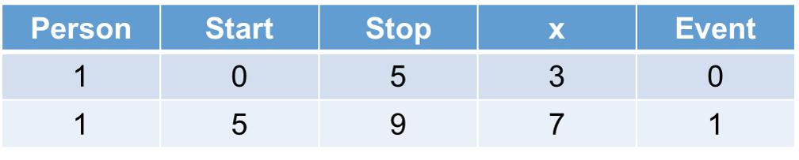

Counting Process Example

In the first observation, our observation starts at time 0 and stops at time 5 with the event being censored since it has yet to occur. The value of our time dependent variable $x$ is 3. In the second observation, our observation starts at time 5 and stops at time 9 where the event occurs. Notice however that the time dependent variable $x$ has a value of 7. This structure must be done for each original observation across each of the variables changing over time.

The most difficult part of modeling time-dependent variables is the formatting of the data correctly. This is rather tedious but typically straight-forward. R requires the data be structured in this way, while SAS will do this for you. Every other step of modeling is the same.

Let’s examine how to incorporate time-dependent variables in each of our softwares!

#### SAS

As mentioned above, SAS will implement the time-dependent variables without needing the counting process structure as long as you have separate columns of data for each time varying predictor variable at each time point. In our prisoner recidivism data set we have variables *emp1* through *emp52* as binary flags for full time employment during that week. Using the `array` statement, we can define the `emp(*)` array using the *emp1* through *emp52* variables. It is easiest to do this if your variables are only different in numerical value at the end of their name. We then create an *employed* variable which flags if the individual is employed for each week. This is also added to our `model` statement. Again, this is *NOT* a variable flagging if as individual was employed at their week of arrest. It is a variable that notes the individual’s employment at each week and takes that into account in the estimation of the variable.

```
ods html select ParameterEstimates;
proc phreg data=Survival.Recid;
    model week*arrest(0)=fin age race wexp mar paro prio employed;
    array emp(*) emp1-emp52;
    employed = emp[week];
run;
```

| Analysis of Maximum Likelihood Estimates Parameter | Analysis of Maximum Likelihood Estimates DF | Analysis of Maximum Likelihood Estimates Parameter Estimate | Analysis of Maximum Likelihood Estimates Standard Error | Analysis of Maximum Likelihood Estimates Chi-Square | Analysis of Maximum Likelihood Estimates Pr > ChiSq | Analysis of Maximum Likelihood Estimates Hazard Ratio |
| --- | --- | --- | --- | --- | --- | --- |
| fin | 1 | -0.35605 | 0.19111 | 3.4708 | 0.0625 | 0.700 |
| age | 1 | -0.04611 | 0.02172 | 4.5093 | 0.0337 | 0.955 |
| race | 1 | 0.33857 | 0.30963 | 1.1957 | 0.2742 | 1.403 |
| wexp | 1 | -0.02753 | 0.21133 | 0.0170 | 0.8964 | 0.973 |
| mar | 1 | -0.29289 | 0.38294 | 0.5850 | 0.4444 | 0.746 |
| paro | 1 | -0.06443 | 0.19469 | 0.1095 | 0.7407 | 0.938 |
| prio | 1 | 0.08467 | 0.02894 | 8.5631 | 0.0034 | 1.088 |
| employed | 1 | -1.32450 | 0.25072 | 27.9067 | <.0001 | 0.266 |

From the above results, we can see that the *employed* variable is significant with a negative coefficient. That means that being employed statistically reduces the hazard of rearrest for each week.

We can use the power of the array to also evaluate shifts in time for employment. In the example below, we evaluate if being employed full time the previous week has an impact on the current week’s hazard of rearrest with similar significant results.

```
ods html select ParameterEstimates;
proc phreg data=Survival.Recid;
    model week*arrest(0)=fin age race wexp mar paro prio employed_lag;
    array emp(*) emp1-emp52;
    employed_lag = emp[week-1];
run;
```

| Analysis of Maximum Likelihood Estimates Parameter | Analysis of Maximum Likelihood Estimates DF | Analysis of Maximum Likelihood Estimates Parameter Estimate | Analysis of Maximum Likelihood Estimates Standard Error | Analysis of Maximum Likelihood Estimates Chi-Square | Analysis of Maximum Likelihood Estimates Pr > ChiSq | Analysis of Maximum Likelihood Estimates Hazard Ratio |
| --- | --- | --- | --- | --- | --- | --- |
| fin | 1 | -0.35057 | 0.19180 | 3.3407 | 0.0676 | 0.704 |
| age | 1 | -0.04957 | 0.02187 | 5.1378 | 0.0234 | 0.952 |
| race | 1 | 0.32158 | 0.30914 | 1.0821 | 0.2982 | 1.379 |
| wexp | 1 | -0.04915 | 0.21314 | 0.0532 | 0.8176 | 0.952 |
| mar | 1 | -0.34451 | 0.38311 | 0.8087 | 0.3685 | 0.709 |
| paro | 1 | -0.04738 | 0.19630 | 0.0583 | 0.8093 | 0.954 |
| prio | 1 | 0.09157 | 0.02878 | 10.1261 | 0.0015 | 1.096 |
| employed_lag | 1 | -0.78379 | 0.21809 | 12.9155 | 0.0003 | 0.457 |

#### R

As mentioned above, R will require the implemention of the counting process to evaluate the time-dependent variables. In our prisoner recidivism data set we have variables *emp1* through *emp52* as binary flags for full time employment during that week. The `recid_long` data set uses these variables to create the counting process structure for the data. We then create an *employed* variable which flags if the individual is employed for each week. It is then put into the usual structure of the `coxph` function with the newly created *employed* variable from the new data set. Again, this is *NOT* a variable flagging if as individual was employed at their week of arrest. It is a variable that notes the individual’s employment at each week and takes that into account in the estimation of the variable.

```r
recid_long.ph <- coxph(Surv(start, stop, arrested == 1) ~ fin + age + race + wexp + mar + paro + prio + employed, data = recid_long)
summary(recid_long.ph)
```

```
Call:
coxph(formula = Surv(start, stop, arrested == 1) ~ fin + age +
    race + wexp + mar + paro + prio + employed, data = recid_long)

  n= 19809, number of events= 114

             coef exp(coef) se(coef)      z Pr(>|z|)
fin      -0.35672   0.69997  0.19113 -1.866  0.06198 .
age      -0.04634   0.95472  0.02174 -2.132  0.03301 *
race      0.33866   1.40306  0.30960  1.094  0.27402
wexp     -0.02555   0.97477  0.21142 -0.121  0.90380
mar      -0.29375   0.74546  0.38303 -0.767  0.44314
paro     -0.06421   0.93781  0.19468 -0.330  0.74156
prio      0.08514   1.08887  0.02896  2.940  0.00328 **
employed -1.32832   0.26492  0.25072 -5.298 1.17e-07 ***
---
Signif. codes:  0 '***' 0.001 '**' 0.01 '*' 0.05 '.' 0.1 ' ' 1

         exp(coef) exp(-coef) lower .95 upper .95
fin         0.7000     1.4286    0.4813    1.0180
age         0.9547     1.0474    0.9149    0.9963
race        1.4031     0.7127    0.7648    2.5740
wexp        0.9748     1.0259    0.6441    1.4753
mar         0.7455     1.3414    0.3519    1.5793
paro        0.9378     1.0663    0.6403    1.3735
prio        1.0889     0.9184    1.0288    1.1525
employed    0.2649     3.7747    0.1621    0.4330

Concordance= 0.708  (se = 0.023 )
Likelihood ratio test= 68.65  on 8 df,   p=9e-12
Wald test            = 56.15  on 8 df,   p=3e-09
Score (logrank) test = 64.48  on 8 df,   p=6e-11
```

From the above results, we can see that the *employed* variable is significant with a negative coefficient. That means that being employed statistically reduces the hazard of rearrest for each week.

We can use the power of the array to also evaluate shifts in time for employment. In the example below, we evaluate if being employed full time the previous week has an impact on the current week’s hazard of rearrest with similar significant results.

```r
recid_lag.ph <- coxph(Surv(start, stop, arrested == 1) ~ fin + age + race + wexp + mar + paro + prio + employed, data = recid_lag)
summary(recid_lag.ph)
```

```
Call:
coxph(formula = Surv(start, stop, arrested == 1) ~ fin + age +
    race + wexp + mar + paro + prio + employed, data = recid_lag)

  n= 19377, number of events= 113

             coef exp(coef) se(coef)      z Pr(>|z|)
fin      -0.35130   0.70377  0.19181 -1.831 0.067035 .
age      -0.04977   0.95144  0.02189 -2.274 0.022969 *
race      0.32147   1.37915  0.30912  1.040 0.298369
wexp     -0.04764   0.95348  0.21323 -0.223 0.823207
mar      -0.34476   0.70839  0.38322 -0.900 0.368310
paro     -0.04710   0.95399  0.19630 -0.240 0.810375
prio      0.09199   1.09635  0.02880  3.194 0.001402 **
employed -0.78689   0.45526  0.21808 -3.608 0.000308 ***
---
Signif. codes:  0 '***' 0.001 '**' 0.01 '*' 0.05 '.' 0.1 ' ' 1

         exp(coef) exp(-coef) lower .95 upper .95
fin         0.7038     1.4209    0.4832    1.0250
age         0.9514     1.0510    0.9115    0.9932
race        1.3792     0.7251    0.7525    2.5278
wexp        0.9535     1.0488    0.6278    1.4481
mar         0.7084     1.4116    0.3343    1.5013
paro        0.9540     1.0482    0.6493    1.4016
prio        1.0964     0.9121    1.0362    1.1600
employed    0.4553     2.1966    0.2969    0.6981

Concordance= 0.67  (se = 0.026 )
Likelihood ratio test= 47.16  on 8 df,   p=1e-07
Wald test            = 43.37  on 8 df,   p=7e-07
Score (logrank) test = 46.4  on 8 df,   p=2e-07
```

# Competing Risks

All of the models used so far have been studying the time until **one** event occurs. However, all of these models can be used extended to studying **multiple** events or **multiple types** of events. The idea of **competing risks** is that each observation can experience only one of several *mutually exclusive* possible events. If an observation experiences another type of event, it is censored for the event we are studying.

In competing risks we still have a notion of independence. Remember from above, we assume the event time $T_i$ and censor time $C_i$ are independent - observations censored at time $t$ were randomly selected to be censored from all observations still in the risk set at time $t$.What does independence mean in this context? In competing risks, independence implies that a censored observation and an uncensored observation have the same risk of the event, regardless of the reason for censoring. In other words, by treating other failure types as censored, even if one of those other failures happens, we assume that has no impact on the time of failure for the event of interest. There is **NO** formal test for this. We must decide based on context of the problem. In other words, are observations with a high risk of one event equally likely to experience the other events?

Since we have multiple types of events, we will be working with a different data set. The world leaders data set was compiled by Bienen and van de Walle in 1991. It looked at primary leaders of all countries between 1960 and 1987. It recorded the number of years the leader was in power and the manner in which they lost power displayed in the pie chart below:

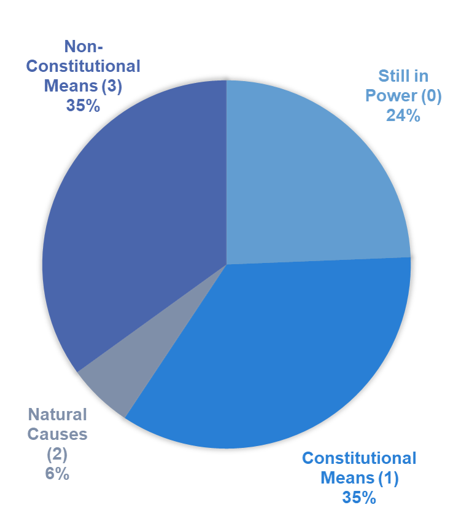

World Leaders Data Set

We want to try and build a survival analysis model for the tenure of world leaders and use the following variables to measure their impact.

World Leaders Data Dictionary

| Variable | Description |
| --- | --- |
| Manner | how the leader reached power (0: constitutional, 1: non-constitutional) |
| Start | year of entry to power |
| Military | background of leader (1: military, 0: civilian) |
| Age | age at time of entry |
| Conflict | level of ethnic conflict (1: medium/high, 0: low) |
| LogInc | log of GNP per capita |
| Growth | avg. annual growth rate of GNP |
| Pop | population in millions |
| Land | land area in 1000 squared km |
| Literacy | literacy rate (unknown year) |
| Region | 0: Middle East, 1: Africa, 2: Asia, 3: Latin America |

## Estimation

Remember, there are two major functions in survival analysis:

- Survival function - probability of surviving beyond time $t$

$$S(t) = P(T>t)=1-F(t)$$

- Hazard function - conditional failure rate in an interval:

$$h(t) = \lim_{\Delta t \rightarrow 0} \frac{P(t<T<t+\Delta t | T>t)}{\Delta t}$$

When there are multiple event types, the hazard function contains two variables - $T$ and $J$. Here, $J$ is the type of event. The cause/specific hazard function is as follows:

$$h_{i,j}(t) = \lim_{\Delta t \rightarrow 0} \frac{P(t<T_i<t+\Delta t, J_i=j | T_i>t)}{\Delta t}$$
THe interpretation stays the same, just it is now type specific. The total hazard for an observation $i$ is then just the sum of the type specific hazards:

$$h_i(t)=\sum_{j} h_{i,j}(t)$$

The **cumulative incidence function** (CIF) is the *unconditional* probability that event type $k$ occurs by time $t$:

$$F_k(t)=P(T\le t, K=k)$$

The probability of **any** event by time $t$ is just the sum of the individual CIF’s:

$$F(t) = \sum_k F_k (t)$$

The overall survival function is still unconditional, since survival means surviving **all** of the risks.

$$S(t) = P(T>t) = 1-F(t) = 1-\sum_k F_k (t)$$

This means there is no such thing as a cause/type specific survival function.

We can estimate the CIF’s nonparametrically using the nonparametric estimates of the survival and hazard functions.

Let’s see how to do this in each of our softwares!

### SAS

SAS uses PROC LIFETEST to build the CIF’s. This is the same procedure we used for developing the Kaplan-Meier estimates of the survival curve. The options are relatively the same as before as well. The `plots = cif(CL)` option provides a graphical representation of the CIF. The `conftype = loglog` option specifies the needed loglog transformation to obtain the confidence interval estimates for the CIF. The `error = delta` option speficies the delta variance method of the CIF estimator. The `time` statement is as before where we have the two pieces of our target variable - the tenure and the censor flag. The `failcode` option specifies the event type we are interested in. Here we are just looking at the event type 1 - constitutional removal from power.

```
proc lifetest data=Survival.leaders plots=cif(CL) conftype=loglog error=delta;
    time years*lost(0) / failcode=1;
    format lost lost.;
run;
```

Failed Event: lost=Constitutional

| Summary of Failure Outcomes Failed Events | Summary of Failure Outcomes Competing Events | Summary of Failure Outcomes Censored | Summary of Failure Outcomes Total |
| --- | --- | --- | --- |
| 165 | 192 | 115 | 472 |

| Cumulative Incidence Function Estimates years | Cumulative Incidence Function Estimates Cumulative Incidence | Cumulative Incidence Function Estimates Standard Error | Cumulative Incidence Function Estimates 95% Confidence Interval | Cumulative Incidence Function Estimates 95% Confidence Interval |
| --- | --- | --- | --- | --- |
| 0 | 0 | 0 | . | . |
| 0 | 0.0932 | 0.0134 | 0.0691 | 0.1215 |
| 1 | 0.1407 | 0.0161 | 0.1110 | 0.1739 |
| 2 | 0.1744 | 0.0176 | 0.1414 | 0.2103 |
| 3 | 0.2161 | 0.0193 | 0.1796 | 0.2550 |
| 4 | 0.2738 | 0.0211 | 0.2332 | 0.3159 |
| 5 | 0.3158 | 0.0222 | 0.2728 | 0.3596 |
| 6 | 0.3395 | 0.0228 | 0.2952 | 0.3842 |
| 8 | 0.3515 | 0.0231 | 0.3064 | 0.3968 |
| 10 | 0.3585 | 0.0234 | 0.3129 | 0.4043 |
| 11 | 0.3661 | 0.0237 | 0.3198 | 0.4124 |
| 12 | 0.3699 | 0.0238 | 0.3233 | 0.4165 |
| 14 | 0.3742 | 0.0240 | 0.3271 | 0.4211 |
| 17 | 0.3850 | 0.0247 | 0.3365 | 0.4331 |
| 20 | 0.3997 | 0.0260 | 0.3486 | 0.4502 |
| 22 | 0.4103 | 0.0273 | 0.3565 | 0.4632 |
| 24 | 0.4316 | 0.0318 | 0.3687 | 0.4927 |

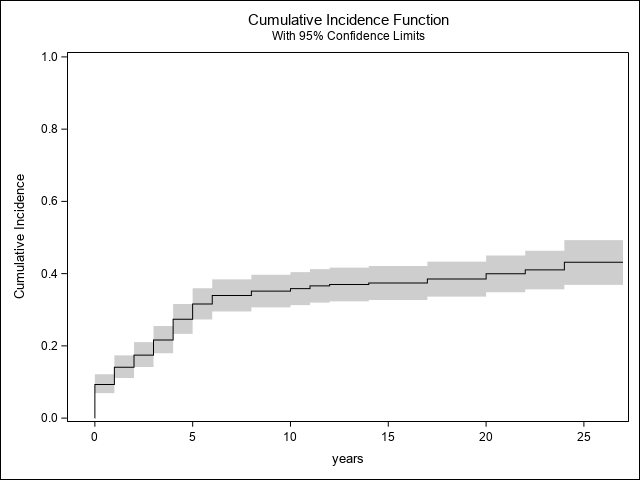

As you can see above, SAS nonparametrically estimates the CIF function for every time point and provides those estimates along with their confidence intervals. To view the three CIF’s for our data’s three event types, the code below changes the previous `failcode` option to now include all three event types 1, 2, and 3. We also use the `outcif =` option to store the CIF’s in their own data set so we can plot them all together using PROC SGPLOT and the `group =` option to specify the failcodes.

```
proc lifetest data=Survival.leaders plots=cif(CL) conftype=loglog error=delta outcif=cif_est noprint;
    time years*lost(0) / failcode=1 2 3;
    format lost lost.;
run;

proc sgplot data=cif_est;
    styleattrs datacolors=(darkblue darkred darkorange) datacontrastcolors=(darkblue darkred darkorange);
    series x=years y=CIF / group=failcode;
    format failcode lost.;
run;
quit;
```

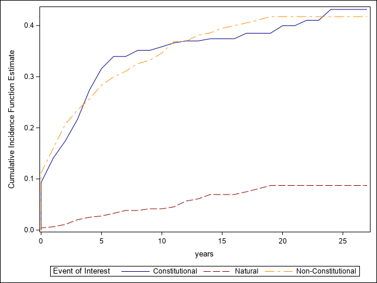

Let’s look at the plot above. It appears as the constitutional and non-constitutional event types have more similar CIF’s then the natural causes event type. This isn’t too surprising as a world leader dying in office is rare and would take time, where the other means of losing power would be expected to happen quicker.

### R

R uses the `finegray` function to help build the CIF’s in the `survfit` function. The structure is a little different than previous functions. The first thing we define is our `Surv` object in the `finegray` function. This function will structure our data into the proper competing risks format to calculate our CIF’s. We need our data to have a start time, stop time, and event status to calculate the CIF’s in the `survfit` function. The `etype =` option specifies the event type of interest to construct the CIF around.

Next, we input the new data objects into their own `survfit` functions. The `Surv` object still defines the target variable, now in three pieces - start, stop, and event status. We are not stratifying our results so we use the `~ 1` formula instead of inputting any variables. The `data =` option defines our finegray data set and the `weight =` option defines any weights created in the finegray function.

Now we have our three CIF’s. We combine them into a list to then plot in the `ggsurvplot` function.

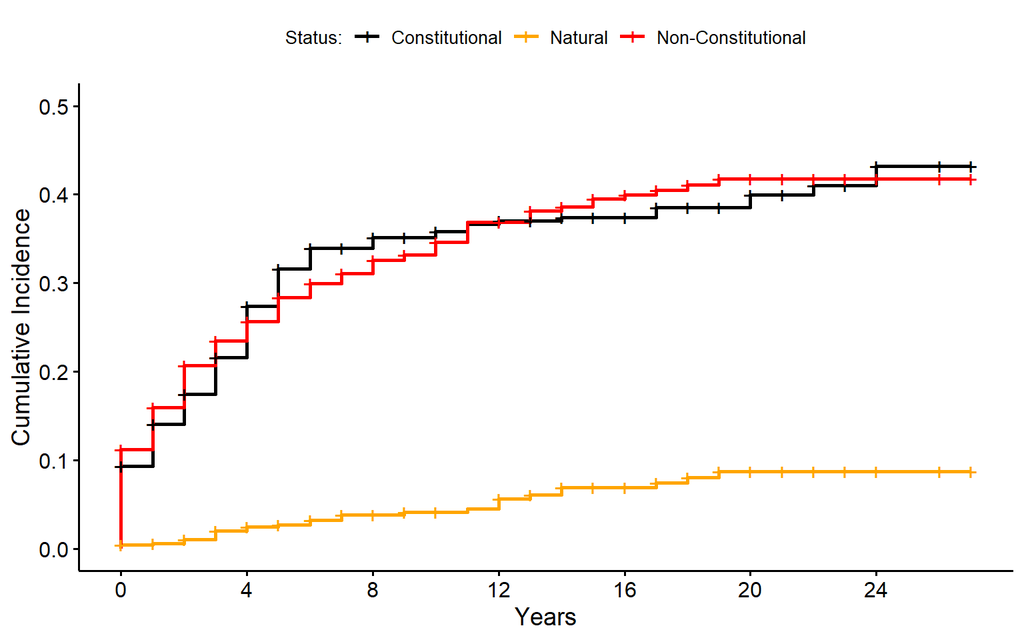

```r
lcon_data <- finegray(Surv(years, lost) ~ .,
                      data = leaders, etype = "Constitutional")
lnat_data <- finegray(Surv(years, lost) ~ .,
                      data = leaders, etype = "Natural")
lnon_data <- finegray(Surv(years, lost) ~ .,
                      data = leaders, etype = "Non-Constitutional")

lcon <- survfit(Surv(fgstart, fgstop, fgstatus) ~ 1,
                data = lcon_data, weight = fgwt)
lnat <- survfit(Surv(fgstart, fgstop, fgstatus) ~ 1,
                data = lnat_data, weight = fgwt)
lnon <- survfit(Surv(fgstart, fgstop, fgstatus) ~ 1,
                data = lnon_data, weight = fgwt)

leadlist <- list(constitutional = lcon, natural = lnat, nonconstitutional = lnon)

ggsurvplot(leadlist, combine = TRUE, fun = "event", conf.int = FALSE,
           break.x.by = 4, ylim = c(0, 0.5), legend.title = "Status:",
           legend.labs = c("Constitutional", "Natural", "Non-Constitutional"), break.y.by = 0.1, xlab = "Years",
           ylab = "Cumulative Incidence", palette = c("black", "orange", "red"))
```

Let’s look at the plot above. It appears as the constitutional and non-constitutional event types have more similar CIF’s then the natural causes event type. This isn’t too surprising as a world leader dying in office is rare and would take time, where the other means of losing power would be expected to happen quicker.

## Cause-Specific Hazard Model

Type specific events can be modeled with both proportional hazard models and accelerated failure time models.

Typically, the modeling approach for competing risks is the use separate Cox regression models for **each** type of event, treating all other events as censored. Essentially, we are modeling the effects of predictors on the cause-specific hazard instead of the overall hazard.

Let’s see how to do this in each of our softwares!

### SAS

We still use the exact same structure to modeling our type specific hazards as we did for our overall hazards in the Cox regression model section of the notes. PROC PHREG will build the model of the leaders data set. The `class` statement is used for our *region* categorical variable. The `model` statement contains both pieces of our target variable on the left hand side of the equal sign. The only difference is that we have many different values for the *lost* variable that are censored. Here the values of 0 (still in power), 1 (constitutionally removed), and 3 (non-constitutionally removed) are all censor events for leaving due to natural causes. The remainder of the procedure is like we have defined before.

```
ods select html FitStatistics ConvergenceStatus ParameterEstimates;
proc phreg data=Survival.Leaders;
    class region;
    model years*lost(0,1,3) = manner start military age conflict loginc growth pop land literacy region / ties=efron;
run;
```

| Convergence Status |
| --- |
| Convergence criterion (GCONV=1E-8) satisfied. |

| Model Fit Statistics Criterion | Model Fit Statistics Without Covariates | Model Fit Statistics With Covariates |
| --- | --- | --- |
| -2 LOG L | 257.293 | 224.870 |
| AIC | 257.293 | 250.870 |
| SBC | 257.293 | 267.716 |

| Analysis of Maximum Likelihood Estimates Parameter | Analysis of Maximum Likelihood Estimates | Analysis of Maximum Likelihood Estimates DF | Analysis of Maximum Likelihood Estimates Parameter Estimate | Analysis of Maximum Likelihood Estimates Standard Error | Analysis of Maximum Likelihood Estimates Chi-Square | Analysis of Maximum Likelihood Estimates Pr > ChiSq | Analysis of Maximum Likelihood Estimates Hazard Ratio | Analysis of Maximum Likelihood Estimates Label |
| --- | --- | --- | --- | --- | --- | --- | --- | --- |
| manner |  | 1 | 0.37473 | 0.66325 | 0.3192 | 0.5721 | 1.455 |  |
| start |  | 1 | -0.05403 | 0.03386 | 2.5463 | 0.1106 | 0.947 |  |
| military |  | 1 | -0.36461 | 0.74091 | 0.2422 | 0.6226 | 0.694 |  |
| age |  | 1 | 0.07386 | 0.01840 | 16.1192 | <.0001 | 1.077 |  |
| conflict |  | 1 | -0.26085 | 0.47196 | 0.3055 | 0.5805 | 0.770 |  |
| loginc |  | 1 | 0.32854 | 0.26732 | 1.5105 | 0.2191 | 1.389 |  |
| growth |  | 1 | 0.08816 | 0.08518 | 1.0712 | 0.3007 | 1.092 |  |
| pop |  | 1 | 0.00199 | 0.00214 | 0.8676 | 0.3516 | 1.002 |  |
| land |  | 1 | -0.0000397 | 0.0001781 | 0.0497 | 0.8237 | 1.000 |  |
| literacy |  | 1 | -0.00880 | 0.01260 | 0.4876 | 0.4850 | 0.991 |  |
| region | 0 | 1 | -0.65910 | 0.78519 | 0.7046 | 0.4012 | 0.517 | region 0 |
| region | 1 | 1 | -1.30176 | 0.80525 | 2.6134 | 0.1060 | 0.272 | region 1 |
| region | 2 | 1 | -1.43672 | 0.76049 | 3.5691 | 0.0589 | 0.238 | region 2 |

Let’s examine the results above. The results are in the exact same format as described before in the notes about the Cox regression model. Here we can see that *age* appears to really be the only significant variable to predict the event of natural causes forcing a change in power. This is not surprising since older leaders have a higher chance in dying while in power.

Only the parameter estimates are provided for the remaining two Cox regression models for the events of leaving power due to constitutional and non-constitutional means respectively.

```
ods select html ParameterEstimates;
proc phreg data=Survival.Leaders;
    class region;
    model years*lost(0,2,3) = manner start military age conflict loginc growth pop land literacy region / ties=efron;
run;

ods select html ParameterEstimates;
proc phreg data=Survival.Leaders;
    class region;
    model years*lost(0,1,2) = manner start military age conflict loginc growth pop land literacy region / ties=efron;
run;
```

| Analysis of Maximum Likelihood Estimates Parameter | Analysis of Maximum Likelihood Estimates | Analysis of Maximum Likelihood Estimates DF | Analysis of Maximum Likelihood Estimates Parameter Estimate | Analysis of Maximum Likelihood Estimates Standard Error | Analysis of Maximum Likelihood Estimates Chi-Square | Analysis of Maximum Likelihood Estimates Pr > ChiSq | Analysis of Maximum Likelihood Estimates Hazard Ratio | Analysis of Maximum Likelihood Estimates Label |
| --- | --- | --- | --- | --- | --- | --- | --- | --- |
| manner |  | 1 | -0.31919 | 0.25780 | 1.5329 | 0.2157 | 0.727 |  |
| start |  | 1 | 0.00112 | 0.01187 | 0.0088 | 0.9251 | 1.001 |  |
| military |  | 1 | -0.01264 | 0.25963 | 0.0024 | 0.9612 | 0.987 |  |
| age |  | 1 | 0.02620 | 0.00870 | 9.0632 | 0.0026 | 1.027 |  |
| conflict |  | 1 | -0.10672 | 0.20377 | 0.2743 | 0.6005 | 0.899 |  |
| loginc |  | 1 | -0.14817 | 0.11813 | 1.5733 | 0.2097 | 0.862 |  |
| growth |  | 1 | 0.02992 | 0.03350 | 0.7977 | 0.3718 | 1.030 |  |
| pop |  | 1 | 0.0004694 | 0.0008426 | 0.3104 | 0.5774 | 1.000 |  |
| land |  | 1 | -0.0000250 | 0.0000705 | 0.1261 | 0.7225 | 1.000 |  |
| literacy |  | 1 | 0.01343 | 0.00571 | 5.5302 | 0.0187 | 1.014 |  |
| region | 0 | 1 | -0.46097 | 0.33374 | 1.9077 | 0.1672 | 0.631 | region 0 |
| region | 1 | 1 | -1.52699 | 0.37303 | 16.7563 | <.0001 | 0.217 | region 1 |
| region | 2 | 1 | -0.48203 | 0.23922 | 4.0603 | 0.0439 | 0.618 | region 2 |

| Analysis of Maximum Likelihood Estimates Parameter | Analysis of Maximum Likelihood Estimates | Analysis of Maximum Likelihood Estimates DF | Analysis of Maximum Likelihood Estimates Parameter Estimate | Analysis of Maximum Likelihood Estimates Standard Error | Analysis of Maximum Likelihood Estimates Chi-Square | Analysis of Maximum Likelihood Estimates Pr > ChiSq | Analysis of Maximum Likelihood Estimates Hazard Ratio | Analysis of Maximum Likelihood Estimates Label |
| --- | --- | --- | --- | --- | --- | --- | --- | --- |
| manner |  | 1 | 0.94017 | 0.22027 | 18.2176 | <.0001 | 2.560 |  |
| start |  | 1 | -0.03408 | 0.01213 | 7.8971 | 0.0050 | 0.966 |  |
| military |  | 1 | -0.41427 | 0.22619 | 3.3545 | 0.0670 | 0.661 |  |
| age |  | 1 | 0.00840 | 0.00836 | 1.0097 | 0.3150 | 1.008 |  |
| conflict |  | 1 | 0.54223 | 0.20113 | 7.2676 | 0.0070 | 1.720 |  |
| loginc |  | 1 | -0.42656 | 0.14043 | 9.2266 | 0.0024 | 0.653 |  |
| growth |  | 1 | -0.04915 | 0.03081 | 2.5450 | 0.1106 | 0.952 |  |
| pop |  | 1 | -0.0009570 | 0.00149 | 0.4151 | 0.5194 | 0.999 |  |
| land |  | 1 | 0.0000174 | 0.0000784 | 0.0492 | 0.8245 | 1.000 |  |
| literacy |  | 1 | -0.00567 | 0.00448 | 1.6062 | 0.2050 | 0.994 |  |
| region | 0 | 1 | -0.51773 | 0.31792 | 2.6519 | 0.1034 | 0.596 | region 0 |
| region | 1 | 1 | -0.91866 | 0.27940 | 10.8108 | 0.0010 | 0.399 | region 1 |
| region | 2 | 1 | -1.27634 | 0.34360 | 13.7988 | 0.0002 | 0.279 | region 2 |

Code for accerlated failure time models is not shown here, but they have a similar structure to Cox regression models when dealing with competing risks. The only difference is flagging every event that is not currently being modeled as a censored observation. With AFT models, distributions need to be evaluated for all types of failures as different failure types might have different distributions. For more on AFT models, see the previous sections.

### R

We still use the exact same structure to modeling our type specific hazards as we did for our overall hazards in the Cox regression model section of the notes. The `coxph` function will build the model of the leaders data set. The `factor` function is used for our *region* categorical variable. The `Surv` function defines both pieces of our target variable on the left hand side of the formula. As before, R only needs the label for the event of interset. All other events are assumed to be censored. Here the values of 0 (still in power), 1 (constitutionally removed), and 3 (non-constitutionally removed) are all censor events for leaving due to natural causes. The remainder of the function is like we have defined before.

```r
cox_nat <- coxph(Surv(years, lost == "Natural") ~ manner + start + military + age + conflict + loginc + growth + pop + land + literacy + factor(region),
                   data = leaders)
summary(cox_nat)
```

```
Call:
coxph(formula = Surv(years, lost == "Natural") ~ manner + start +
    military + age + conflict + loginc + growth + pop + land +
    literacy + factor(region), data = leaders)

  n= 438, number of events= 27
   (34 observations deleted due to missingness)

                      coef  exp(coef)   se(coef)      z Pr(>|z|)
manner           3.747e-01  1.455e+00  6.633e-01  0.565    0.572
start           -5.403e-02  9.474e-01  3.386e-02 -1.596    0.111
military        -3.646e-01  6.945e-01  7.409e-01 -0.492    0.623
age              7.386e-02  1.077e+00  1.840e-02  4.015 5.95e-05 ***
conflict        -2.609e-01  7.704e-01  4.720e-01 -0.553    0.580
loginc           3.285e-01  1.389e+00  2.673e-01  1.229    0.219
growth           8.817e-02  1.092e+00  8.518e-02  1.035    0.301
pop              1.991e-03  1.002e+00  2.138e-03  0.931    0.352
land            -3.969e-05  1.000e+00  1.781e-04 -0.223    0.824
literacy        -8.796e-03  9.912e-01  1.260e-02 -0.698    0.485
factor(region)1 -6.427e-01  5.259e-01  8.360e-01 -0.769    0.442
factor(region)2 -7.776e-01  4.595e-01  9.031e-01 -0.861    0.389
factor(region)3  6.591e-01  1.933e+00  7.852e-01  0.839    0.401
---
Signif. codes:  0 '***' 0.001 '**' 0.01 '*' 0.05 '.' 0.1 ' ' 1

                exp(coef) exp(-coef) lower .95 upper .95
manner             1.4546     0.6875   0.39644     5.337
start              0.9474     1.0555   0.88657     1.012
military           0.6945     1.4400   0.16255     2.967
age                1.0767     0.9288   1.03853     1.116
conflict           0.7704     1.2980   0.30548     1.943
loginc             1.3889     0.7200   0.82251     2.345
growth             1.0922     0.9156   0.92423     1.291
pop                1.0020     0.9980   0.99780     1.006
land               1.0000     1.0000   0.99961     1.000
literacy           0.9912     1.0088   0.96707     1.016
factor(region)1    0.5259     1.9015   0.10217     2.707
factor(region)2    0.4595     2.1763   0.07827     2.698
factor(region)3    1.9330     0.5173   0.41484     9.007

Concordance= 0.819  (se = 0.046 )
Likelihood ratio test= 32.42  on 13 df,   p=0.002
Wald test            = 29.47  on 13 df,   p=0.006
Score (logrank) test = 33.21  on 13 df,   p=0.002
```

Let’s examine the results above. The results are in the exact same format as described before in the notes about the Cox regression model. Here we can see that *age* appears to really be the only significant variable to predict the event of natural causes forcing a change in power. This is not surprising since older leaders have a higher chance in dying while in power.

The results are provided for the remaining two Cox regression models for the events of leaving power due to constitutional and non-constitutional means respectively.

```r
cox_const <- coxph(Surv(years, lost == "Constitutional") ~ manner + start + military + age + conflict + loginc + growth + pop + land + literacy + factor(region),
                   data = leaders)
summary(cox_const)
```

```
Call:
coxph(formula = Surv(years, lost == "Constitutional") ~ manner +
    start + military + age + conflict + loginc + growth + pop +
    land + literacy + factor(region), data = leaders)

  n= 438, number of events= 146
   (34 observations deleted due to missingness)

                      coef  exp(coef)   se(coef)      z Pr(>|z|)
manner          -3.192e-01  7.267e-01  2.578e-01 -1.238  0.21567
start            1.115e-03  1.001e+00  1.187e-02  0.094  0.92512
military        -1.264e-02  9.874e-01  2.596e-01 -0.049  0.96117
age              2.620e-02  1.027e+00  8.702e-03  3.011  0.00261 **
conflict        -1.067e-01  8.988e-01  2.038e-01 -0.524  0.60046
loginc          -1.482e-01  8.623e-01  1.181e-01 -1.254  0.20973
growth           2.992e-02  1.030e+00  3.350e-02  0.893  0.37179
pop              4.694e-04  1.000e+00  8.426e-04  0.557  0.57745
land            -2.502e-05  1.000e+00  7.047e-05 -0.355  0.72251
literacy         1.343e-02  1.014e+00  5.711e-03  2.352  0.01869 *
factor(region)1 -1.066e+00  3.444e-01  4.122e-01 -2.586  0.00970 **
factor(region)2 -2.106e-02  9.792e-01  3.672e-01 -0.057  0.95427
factor(region)3  4.610e-01  1.586e+00  3.337e-01  1.381  0.16721
---
Signif. codes:  0 '***' 0.001 '**' 0.01 '*' 0.05 '.' 0.1 ' ' 1

                exp(coef) exp(-coef) lower .95 upper .95
manner             0.7267     1.3760    0.4385    1.2045
start              1.0011     0.9989    0.9781    1.0247
military           0.9874     1.0127    0.5936    1.6425
age                1.0265     0.9741    1.0092    1.0442
conflict           0.8988     1.1126    0.6028    1.3400
loginc             0.8623     1.1597    0.6841    1.0869
growth             1.0304     0.9705    0.9649    1.1003
pop                1.0005     0.9995    0.9988    1.0021
land               1.0000     1.0000    0.9998    1.0001
literacy           1.0135     0.9867    1.0022    1.0249
factor(region)1    0.3444     2.9038    0.1535    0.7724
factor(region)2    0.9792     1.0213    0.4767    2.0112
factor(region)3    1.5856     0.6307    0.8244    3.0499

Concordance= 0.735  (se = 0.021 )
Likelihood ratio test= 106.1  on 13 df,   p=<2e-16
Wald test            = 78.78  on 13 df,   p=2e-11
Score (logrank) test = 96.8  on 13 df,   p=7e-15
```

```r
cox_noncon <- coxph(Surv(years, lost == "Non-Constitutional") ~ manner + start + military + age + conflict + loginc + growth + pop + land + literacy + factor(region),
                   data = leaders)
summary(cox_noncon)
```

```
Call:
coxph(formula = Surv(years, lost == "Non-Constitutional") ~ manner +
    start + military + age + conflict + loginc + growth + pop +
    land + literacy + factor(region), data = leaders)

  n= 438, number of events= 154
   (34 observations deleted due to missingness)

                      coef  exp(coef)   se(coef)      z Pr(>|z|)
manner           9.402e-01  2.561e+00  2.203e-01  4.269 1.97e-05 ***
start           -3.408e-02  9.665e-01  1.213e-02 -2.810  0.00495 **
military        -4.143e-01  6.608e-01  2.262e-01 -1.832  0.06698 .
age              8.409e-03  1.008e+00  8.364e-03  1.005  0.31467
conflict         5.423e-01  1.720e+00  2.011e-01  2.696  0.00701 **
loginc          -4.268e-01  6.526e-01  1.404e-01 -3.039  0.00237 **
growth          -4.915e-02  9.520e-01  3.081e-02 -1.595  0.11066
pop             -9.563e-04  9.990e-01  1.485e-03 -0.644  0.51967
land             1.736e-05  1.000e+00  7.841e-05  0.221  0.82483
literacy        -5.672e-03  9.943e-01  4.477e-03 -1.267  0.20517
factor(region)1 -4.011e-01  6.696e-01  3.116e-01 -1.287  0.19803
factor(region)2 -7.593e-01  4.680e-01  4.110e-01 -1.848  0.06467 .
factor(region)3  5.178e-01  1.678e+00  3.179e-01  1.629  0.10337
---
Signif. codes:  0 '***' 0.001 '**' 0.01 '*' 0.05 '.' 0.1 ' ' 1

                exp(coef) exp(-coef) lower .95 upper .95
manner             2.5606     0.3905    1.6628    3.9431
start              0.9665     1.0347    0.9438    0.9897
military           0.6608     1.5134    0.4242    1.0294
age                1.0084     0.9916    0.9920    1.0251
conflict           1.7200     0.5814    1.1596    2.5511
loginc             0.6526     1.5324    0.4955    0.8594
growth             0.9520     1.0504    0.8963    1.0113
pop                0.9990     1.0010    0.9961    1.0020
land               1.0000     1.0000    0.9999    1.0002
literacy           0.9943     1.0057    0.9857    1.0031
factor(region)1    0.6696     1.4935    0.3635    1.2333
factor(region)2    0.4680     2.1367    0.2091    1.0473
factor(region)3    1.6784     0.5958    0.9000    3.1297

Concordance= 0.714  (se = 0.023 )
Likelihood ratio test= 84.68  on 13 df,   p=1e-12
Wald test            = 71.8  on 13 df,   p=4e-10
Score (logrank) test = 76.27  on 13 df,   p=6e-11
```

Code for accerlated failure time models is not shown here, but they have a similar structure to Cox regression models when dealing with competing risks. The only difference is flagging every event that is not currently being modeled as a censored observation. With AFT models, distributions need to be evaluated for all types of failures as different failure types might have different distributions. For more on AFT models, see the previous sections.

## Conditional Processes

The competing risks approach presumes that each event type has its own hazard that governs **both** the occurrence and timing of events of that type. They are assumed to be independent processes acting in parallel with each other. For example, death due to natural causes vs. forcible removal from power in our leaders data set.

In a business setting, this independence assumption rarely seems reasonable. For example, consider the event to be buying a personal computer. There are two types of computer you are potentially buying - an Apple or a Mac. There are **not** two independent processes where we see what happens first. One process governs when you will buy a computer, while another process determines the choice of the computer. **Conditional processes** occur when these events are not independent of each other and are conditional on each other. There are two common approaches to conditional process modeling:

1. Two-Stage Modeling
2. Fine-Gray Model

### Two-Stage Modeling

Two-stage modeling is a rather straight-forward approach. You model each of the stages (time and event) separately.

1. Survival analysis - when will any event occur
2. Classification model - what ype of event occurs

From our previous example of buying a computer, we would build a survival analysis to determine when we would buy another computer and a classification model (say logistic regression) on which type of computer we would buy.

### Fine-Gray Model

The Fine-Gray approach to modeling conditional processes focuses on modeling **sub-hazards**. By treating non-$k$ events as censored, in Cox regression modeling, you are modeling the cause-specific hazard:

$$h_{k} (t) = -\frac{d}{dt}\log (1-F(t))$$
which the the rate of event $k$ for those still at risk at time $t$ conditional on *no event happening yet*.

Instead, we could take the CIF’s and look at the **sub-hazard**:

$$h^*_{k} (t) = -\frac{d}{dt}\log (1-F_k (t))$$
which is the rate of event $k$ for those still at risk at time $t$ conditional on *event* $k$ *not happening yet*.

The Fine-Gray model replaces the cause-specific hazard with the sub-hazard to get a proportional sub-hazard model:

$$\log h^*_k (t)=\log h^*_{0,k} (t) + \beta_1 x_{i,1} + \cdots + \beta_k x_{i,k}$$

By using the CIF’s rather than the overall survival function (using $1-F_k(t)$ instead of $1-F(t)$), the risk set is adjusted to account for different events happening. Risks are essentially balanced by looking at the probability of one specific event type in the presence of other event types by keeping failures from other causes “at risk” for the particular event type we are focused on. In other words, the other events are still competing risks and not truly treated as censored. This makes your conclusions conditionally focused on the event of interest.

Let’s see how to do this in each of our softwares!

#### SAS

PROC PHREG in SAS will still give us the needed functionality. Instead of flagging events that are not being modeled as censored, the censor variable only makes observations that are truly censored and have yet to experience *any* event. The main difference is the `eventcode =` option where we specify the event of interest. This informs SAS that we want to build the Fine-Gray model for event type 2 (natural causes) while leaving the other events as still competing, but now conditional.

```
ods select html FitStatistics ConvergenceStatus ParameterEstimates;
proc phreg data=Survival.Leaders;
    class region;
    model years*lost(0) = manner start military age conflict loginc growth pop land literacy region / ties=efron rl eventcode=2;
run;
```

| Convergence Status |
| --- |
| Convergence criterion (GCONV=1E-8) satisfied. |

| Model Fit Statistics Criterion | Model Fit Statistics Without Covariates | Model Fit Statistics With Covariates |
| --- | --- | --- |
| -2 LOG L | 307.767 | 282.967 |
| AIC | 307.767 | 308.967 |
| SBC | 307.767 | 325.813 |

| Analysis of Maximum Likelihood Estimates Parameter | Analysis of Maximum Likelihood Estimates | Analysis of Maximum Likelihood Estimates DF | Analysis of Maximum Likelihood Estimates Parameter Estimate | Analysis of Maximum Likelihood Estimates Standard Error | Analysis of Maximum Likelihood Estimates Chi-Square | Analysis of Maximum Likelihood Estimates Pr > ChiSq | Analysis of Maximum Likelihood Estimates Hazard Ratio | Analysis of Maximum Likelihood Estimates 95% Hazard Ratio Confidence Limits | Analysis of Maximum Likelihood Estimates 95% Hazard Ratio Confidence Limits | Analysis of Maximum Likelihood Estimates Label |
| --- | --- | --- | --- | --- | --- | --- | --- | --- | --- | --- |
| manner |  | 1 | -0.02627 | 0.56351 | 0.0022 | 0.9628 | 0.974 | 0.323 | 2.939 |  |
| start |  | 1 | -0.06552 | 0.02931 | 4.9967 | 0.0254 | 0.937 | 0.884 | 0.992 |  |
| military |  | 1 | -0.30013 | 0.54999 | 0.2978 | 0.5853 | 0.741 | 0.252 | 2.177 |  |
| age |  | 1 | 0.04878 | 0.01732 | 7.9273 | 0.0049 | 1.050 | 1.015 | 1.086 |  |
| conflict |  | 1 | -0.01561 | 0.42546 | 0.0013 | 0.9707 | 0.985 | 0.428 | 2.267 |  |
| loginc |  | 1 | 0.52953 | 0.25811 | 4.2090 | 0.0402 | 1.698 | 1.024 | 2.816 |  |
| growth |  | 1 | 0.09748 | 0.12570 | 0.6014 | 0.4380 | 1.102 | 0.862 | 1.410 |  |
| pop |  | 1 | 0.00229 | 0.00274 | 0.6939 | 0.4048 | 1.002 | 0.997 | 1.008 |  |
| land |  | 1 | -0.0000725 | 0.0001846 | 0.1544 | 0.6944 | 1.000 | 1.000 | 1.000 |  |
| literacy |  | 1 | -0.00647 | 0.01081 | 0.3584 | 0.5494 | 0.994 | 0.973 | 1.015 |  |
| region | 0 | 1 | -0.11024 | 0.61842 | 0.0318 | 0.8585 | 0.896 | 0.267 | 3.010 | region 0 |
| region | 1 | 1 | 0.26294 | 0.56181 | 0.2191 | 0.6398 | 1.301 | 0.432 | 3.912 | region 1 |
| region | 2 | 1 | -0.85646 | 0.94601 | 0.8196 | 0.3653 | 0.425 | 0.066 | 2.712 | region 2 |

The parameter estimates for the other two proportional sub-hazard models are displayed below for constitutional and non-constitutional event types respectively.

```
ods select html ParameterEstimates;
proc phreg data=Survival.Leaders;
    class region;
    model years*lost(0) = manner start military age conflict loginc growth pop land literacy region / ties=efron rl eventcode=1;
run;

ods select html ParameterEstimates;
proc phreg data=Survival.Leaders;
    class region;
    model years*lost(0) = manner start military age conflict loginc growth pop land literacy region / ties=efron rl eventcode=3;
run;
```

| Analysis of Maximum Likelihood Estimates Parameter | Analysis of Maximum Likelihood Estimates | Analysis of Maximum Likelihood Estimates DF | Analysis of Maximum Likelihood Estimates Parameter Estimate | Analysis of Maximum Likelihood Estimates Standard Error | Analysis of Maximum Likelihood Estimates Chi-Square | Analysis of Maximum Likelihood Estimates Pr > ChiSq | Analysis of Maximum Likelihood Estimates Hazard Ratio | Analysis of Maximum Likelihood Estimates 95% Hazard Ratio Confidence Limits | Analysis of Maximum Likelihood Estimates 95% Hazard Ratio Confidence Limits | Analysis of Maximum Likelihood Estimates Label |
| --- | --- | --- | --- | --- | --- | --- | --- | --- | --- | --- |
| manner |  | 1 | -0.60756 | 0.26411 | 5.2919 | 0.0214 | 0.545 | 0.325 | 0.914 |  |
| start |  | 1 | 0.00374 | 0.01044 | 0.1286 | 0.7199 | 1.004 | 0.983 | 1.025 |  |
| military |  | 1 | 0.04592 | 0.25164 | 0.0333 | 0.8552 | 1.047 | 0.639 | 1.715 |  |
| age |  | 1 | 0.01307 | 0.00844 | 2.3986 | 0.1214 | 1.013 | 0.997 | 1.030 |  |
| conflict |  | 1 | -0.13423 | 0.21118 | 0.4040 | 0.5250 | 0.874 | 0.578 | 1.323 |  |
| loginc |  | 1 | -0.14935 | 0.11541 | 1.6747 | 0.1956 | 0.861 | 0.687 | 1.080 |  |
| growth |  | 1 | 0.04042 | 0.02989 | 1.8280 | 0.1764 | 1.041 | 0.982 | 1.104 |  |
| pop |  | 1 | 0.0006951 | 0.0009074 | 0.5867 | 0.4437 | 1.001 | 0.999 | 1.002 |  |
| land |  | 1 | -0.0000278 | 0.0000721 | 0.1486 | 0.6999 | 1.000 | 1.000 | 1.000 |  |
| literacy |  | 1 | 0.01998 | 0.00578 | 11.9504 | 0.0005 | 1.020 | 1.009 | 1.032 |  |
| region | 0 | 1 | -0.09556 | 0.35174 | 0.0738 | 0.7859 | 0.909 | 0.456 | 1.811 | region 0 |
| region | 1 | 1 | -1.04075 | 0.34445 | 9.1293 | 0.0025 | 0.353 | 0.180 | 0.694 | region 1 |
| region | 2 | 1 | -0.15656 | 0.21394 | 0.5355 | 0.4643 | 0.855 | 0.562 | 1.300 | region 2 |

| Analysis of Maximum Likelihood Estimates Parameter | Analysis of Maximum Likelihood Estimates | Analysis of Maximum Likelihood Estimates DF | Analysis of Maximum Likelihood Estimates Parameter Estimate | Analysis of Maximum Likelihood Estimates Standard Error | Analysis of Maximum Likelihood Estimates Chi-Square | Analysis of Maximum Likelihood Estimates Pr > ChiSq | Analysis of Maximum Likelihood Estimates Hazard Ratio | Analysis of Maximum Likelihood Estimates 95% Hazard Ratio Confidence Limits | Analysis of Maximum Likelihood Estimates 95% Hazard Ratio Confidence Limits | Analysis of Maximum Likelihood Estimates Label |
| --- | --- | --- | --- | --- | --- | --- | --- | --- | --- | --- |
| manner |  | 1 | 0.79577 | 0.19719 | 16.2861 | <.0001 | 2.216 | 1.506 | 3.262 |  |
| start |  | 1 | -0.03802 | 0.01112 | 11.6777 | 0.0006 | 0.963 | 0.942 | 0.984 |  |
| military |  | 1 | -0.26315 | 0.19991 | 1.7328 | 0.1881 | 0.769 | 0.519 | 1.137 |  |
| age |  | 1 | -0.0007315 | 0.00822 | 0.0079 | 0.9291 | 0.999 | 0.983 | 1.015 |  |
| conflict |  | 1 | 0.54007 | 0.18497 | 8.5254 | 0.0035 | 1.716 | 1.194 | 2.466 |  |
| loginc |  | 1 | -0.34453 | 0.12912 | 7.1199 | 0.0076 | 0.709 | 0.550 | 0.913 |  |
| growth |  | 1 | -0.05173 | 0.02952 | 3.0716 | 0.0797 | 0.950 | 0.896 | 1.006 |  |
| pop |  | 1 | -0.00118 | 0.0008723 | 1.8211 | 0.1772 | 0.999 | 0.997 | 1.001 |  |
| land |  | 1 | -0.0000188 | 0.0000804 | 0.0546 | 0.8153 | 1.000 | 1.000 | 1.000 |  |
| literacy |  | 1 | -0.00867 | 0.00408 | 4.5232 | 0.0334 | 0.991 | 0.983 | 0.999 |  |
| region | 0 | 1 | -0.33606 | 0.29376 | 1.3088 | 0.2526 | 0.715 | 0.402 | 1.271 | region 0 |
| region | 1 | 1 | -0.56321 | 0.25131 | 5.0224 | 0.0250 | 0.569 | 0.348 | 0.932 | region 1 |
| region | 2 | 1 | -0.88660 | 0.29828 | 8.8353 | 0.0030 | 0.412 | 0.230 | 0.739 | region 2 |

#### R

The `finegray` function in R that we used to calculate the CIF’s will alsop be used for the needed functionality. Instead of flagging events that are not being modeled as censored, the censor variable only makes observations that are truly censored and have yet to experience *any* event. The `etype =` option in the `finegray` function informs R that we want to build the Fine-Gray model for event type 2 (natural causes) while leaving the other events as still competing, but now conditional.The main difference is the Fine-Gray data sctructure and input into the `coxph` model with the `Surv` function.

```r
lnat_data <- finegray(Surv(years, lost) ~ .,
                      data = leaders, etype = "Natural")

fg_nat <- coxph(Surv(fgstart, fgstop, fgstatus) ~ manner + start + military + age + conflict + loginc + growth + pop + land + literacy + factor(region),
                 data = lnat_data, weight = fgwt)
summary(fg_nat)
```

```
Call:
coxph(formula = Surv(fgstart, fgstop, fgstatus) ~ manner + start +
    military + age + conflict + loginc + growth + pop + land +
    literacy + factor(region), data = lnat_data, weights = fgwt)

  n= 3650, number of events= 27
   (434 observations deleted due to missingness)

                      coef  exp(coef)   se(coef)  robust se      z Pr(>|z|)
manner          -2.243e-02  9.778e-01  5.895e-01  5.445e-01 -0.041  0.96715
start           -6.584e-02  9.363e-01  2.961e-02  2.843e-02 -2.316  0.02055 *
military        -3.031e-01  7.386e-01  6.564e-01  5.260e-01 -0.576  0.56452
age              4.920e-02  1.050e+00  1.835e-02  1.655e-02  2.972  0.00296 **
conflict        -1.794e-02  9.822e-01  4.808e-01  4.068e-01 -0.044  0.96481
loginc           5.326e-01  1.703e+00  2.606e-01  2.531e-01  2.104  0.03535 *
growth           9.729e-02  1.102e+00  8.441e-02  1.244e-01  0.782  0.43432
pop              2.283e-03  1.002e+00  2.150e-03  2.688e-03  0.849  0.39577
land            -7.216e-05  9.999e-01  1.585e-04  1.789e-04 -0.403  0.68668
literacy        -6.535e-03  9.935e-01  1.258e-02  1.043e-02 -0.626  0.53107
factor(region)1  3.697e-01  1.447e+00  7.384e-01  6.917e-01  0.534  0.59302
factor(region)2 -7.536e-01  4.707e-01  8.341e-01  7.817e-01 -0.964  0.33500
factor(region)3  1.069e-01  1.113e+00  7.141e-01  5.869e-01  0.182  0.85543
---
Signif. codes:  0 '***' 0.001 '**' 0.01 '*' 0.05 '.' 0.1 ' ' 1

                exp(coef) exp(-coef) lower .95 upper .95
manner             0.9778     1.0227    0.3364    2.8427
start              0.9363     1.0681    0.8855    0.9899
military           0.7386     1.3540    0.2634    2.0708
age                1.0504     0.9520    1.0169    1.0851
conflict           0.9822     1.0181    0.4426    2.1800
loginc             1.7033     0.5871    1.0372    2.7973
growth             1.1022     0.9073    0.8636    1.4066
pop                1.0023     0.9977    0.9970    1.0076
land               0.9999     1.0001    0.9996    1.0003
literacy           0.9935     1.0066    0.9734    1.0140
factor(region)1    1.4473     0.6910    0.3731    5.6142
factor(region)2    0.4707     2.1247    0.1017    2.1781
factor(region)3    1.1129     0.8986    0.3522    3.5160

Concordance= 0.751  (se = 0.049 )
Likelihood ratio test= 24.98  on 13 df,   p=0.02
Wald test            = 25.81  on 13 df,   p=0.02
Score (logrank) test = 25.53  on 13 df,   p=0.02,   Robust = 14.28  p=0.4

  (Note: the likelihood ratio and score tests assume independence of
     observations within a cluster, the Wald and robust score tests do not).
```

The parameter estimates for the other two proportional sub-hazard models are displayed below for constitutional and non-constitutional event types respectively.

```r
lcon_data <- finegray(Surv(years, lost) ~ .,
                      data = leaders, etype = "Constitutional")

fg_con <- coxph(Surv(fgstart, fgstop, fgstatus) ~ manner + start + military + age + conflict + loginc + growth + pop + land + literacy + factor(region),
                data = lcon_data, weight = fgwt)
summary(fg_con)
```

```
Call:
coxph(formula = Surv(fgstart, fgstop, fgstatus) ~ manner + start +
    military + age + conflict + loginc + growth + pop + land +
    literacy + factor(region), data = lcon_data, weights = fgwt)

  n= 2331, number of events= 146
   (184 observations deleted due to missingness)

                      coef  exp(coef)   se(coef)  robust se      z Pr(>|z|)
manner          -6.263e-01  5.345e-01  2.565e-01  2.519e-01 -2.486 0.012914 *
start            3.989e-03  1.004e+00  1.117e-02  9.791e-03  0.407 0.683679
military         4.823e-02  1.049e+00  2.570e-01  2.463e-01  0.196 0.844768
age              1.360e-02  1.014e+00  8.404e-03  7.799e-03  1.744 0.081083 .
conflict        -1.370e-01  8.720e-01  2.103e-01  2.071e-01 -0.662 0.508265
loginc          -1.527e-01  8.584e-01  1.203e-01  1.124e-01 -1.358 0.174469
growth           4.225e-02  1.043e+00  3.352e-02  2.822e-02  1.498 0.134253
pop              7.030e-04  1.001e+00  8.379e-04  8.926e-04  0.788 0.430902
land            -3.042e-05  1.000e+00  6.928e-05  6.738e-05 -0.452 0.651588
literacy         2.036e-02  1.021e+00  5.820e-03  5.668e-03  3.593 0.000327 ***
factor(region)1 -9.654e-01  3.808e-01  4.083e-01  3.832e-01 -2.520 0.011749 *
factor(region)2 -6.224e-02  9.397e-01  3.642e-01  3.616e-01 -0.172 0.863353
factor(region)3  1.065e-01  1.112e+00  3.340e-01  3.511e-01  0.303 0.761702
---
Signif. codes:  0 '***' 0.001 '**' 0.01 '*' 0.05 '.' 0.1 ' ' 1

                exp(coef) exp(-coef) lower .95 upper .95
manner             0.5345     1.8708    0.3262    0.8759
start              1.0040     0.9960    0.9849    1.0235
military           1.0494     0.9529    0.6476    1.7006
age                1.0137     0.9865    0.9983    1.0293
conflict           0.8720     1.1469    0.5810    1.3086
loginc             0.8584     1.1650    0.6886    1.0700
growth             1.0432     0.9586    0.9870    1.1025
pop                1.0007     0.9993    0.9990    1.0025
land               1.0000     1.0000    0.9998    1.0001
literacy           1.0206     0.9798    1.0093    1.0320
factor(region)1    0.3808     2.6260    0.1797    0.8070
factor(region)2    0.9397     1.0642    0.4626    1.9088
factor(region)3    1.1123     0.8990    0.5590    2.2136

Concordance= 0.743  (se = 0.018 )
Likelihood ratio test= 110  on 13 df,   p=<2e-16
Wald test            = 108.2  on 13 df,   p=<2e-16
Score (logrank) test = 98.3  on 13 df,   p=4e-15,   Robust = 107.4  p=<2e-16

  (Note: the likelihood ratio and score tests assume independence of
     observations within a cluster, the Wald and robust score tests do not).
```

```r
lnon_data <- finegray(Surv(years, lost) ~ .,
                      data = leaders, etype = "Non-Constitutional")

fg_non <- coxph(Surv(fgstart, fgstop, fgstatus) ~ manner + start + military + age + conflict + loginc + growth + pop + land + literacy + factor(region),
                data = lnon_data, weight = fgwt)
summary(fg_non)
```

```
Call:
coxph(formula = Surv(fgstart, fgstop, fgstatus) ~ manner + start +
    military + age + conflict + loginc + growth + pop + land +
    literacy + factor(region), data = lnon_data, weights = fgwt)

  n= 2827, number of events= 154
   (360 observations deleted due to missingness)

                      coef  exp(coef)   se(coef)  robust se      z Pr(>|z|)
manner           8.403e-01  2.317e+00  2.127e-01  1.835e-01  4.579 4.67e-06 ***
start           -3.921e-02  9.615e-01  1.181e-02  1.075e-02 -3.649 0.000264 ***
military        -2.869e-01  7.506e-01  2.209e-01  1.890e-01 -1.518 0.129012
age             -4.100e-04  9.996e-01  8.354e-03  7.966e-03 -0.051 0.958955
conflict         5.692e-01  1.767e+00  2.044e-01  1.760e-01  3.234 0.001220 **
loginc          -3.558e-01  7.006e-01  1.373e-01  1.203e-01 -2.957 0.003106 **
growth          -5.356e-02  9.479e-01  3.090e-02  2.812e-02 -1.904 0.056869 .
pop             -1.157e-03  9.988e-01  1.453e-03  7.558e-04 -1.531 0.125782
land            -1.950e-05  1.000e+00  7.988e-05  7.245e-05 -0.269 0.787802
literacy        -8.557e-03  9.915e-01  4.475e-03  3.801e-03 -2.251 0.024374 *
factor(region)1 -2.305e-01  7.941e-01  3.070e-01  2.693e-01 -0.856 0.392056
factor(region)2 -5.665e-01  5.675e-01  3.998e-01  3.496e-01 -1.620 0.105163
factor(region)3  3.503e-01  1.419e+00  3.136e-01  2.731e-01  1.282 0.199676
---
Signif. codes:  0 '***' 0.001 '**' 0.01 '*' 0.05 '.' 0.1 ' ' 1

                exp(coef) exp(-coef) lower .95 upper .95
manner             2.3170     0.4316    1.6171    3.3199
start              0.9615     1.0400    0.9415    0.9820
military           0.7506     1.3322    0.5183    1.0871
age                0.9996     1.0004    0.9841    1.0153
conflict           1.7669     0.5660    1.2514    2.4948
loginc             0.7006     1.4273    0.5534    0.8869
growth             0.9479     1.0550    0.8970    1.0016
pop                0.9988     1.0012    0.9974    1.0003
land               1.0000     1.0000    0.9998    1.0001
literacy           0.9915     1.0086    0.9841    0.9989
factor(region)1    0.7941     1.2593    0.4684    1.3463
factor(region)2    0.5675     1.7620    0.2860    1.1261
factor(region)3    1.4195     0.7045    0.8311    2.4245

Concordance= 0.725  (se = 0.02 )
Likelihood ratio test= 104.3  on 13 df,   p=2e-16
Wald test            = 143.1  on 13 df,   p=<2e-16
Score (logrank) test = 98.29  on 13 df,   p=4e-15,   Robust = 102.2  p=6e-16

  (Note: the likelihood ratio and score tests assume independence of
     observations within a cluster, the Wald and robust score tests do not).
```

# Repeated Events

Previous sections have analyzed time to a single event and time to one of many types of events. Let’s extend this again to the possibility of multiple occurrences of a single event. **Repeated events**, like competing risks, is a particular type of multi-state analysis that builds upon the previous things we have learned. For some situations/data, it may be informative to consider the event of interest happening more than once:

- Repairs to a machine
- Hospital readmissions
- Defaults on loans

Most techniques are the same, however, the independence of observations no longer applies since an observation can potentially contribute multiple events to the data set.

Since we have repeated events, we will be working with a different data set. The bladder tumors data set was compiled by Andrews and Hertzberg in 1985. It looked at a randomized trial of 85 patients and counted the number of recurrences of bladder tumors. The distribution of the repeated event of bladder tumors is in the pie chart below:

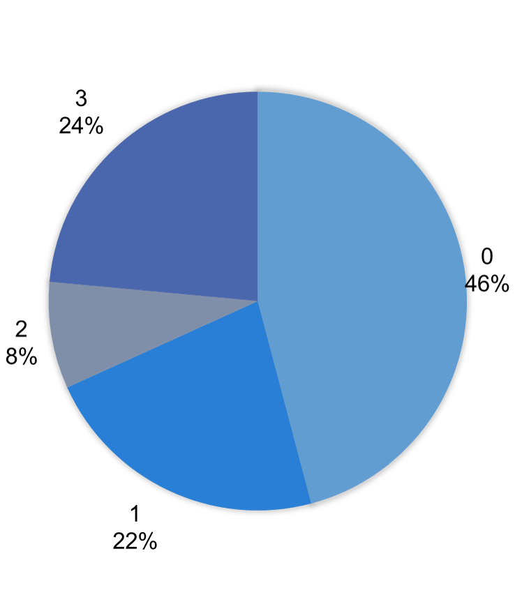

Bladder Tumors Data Set

We want to try and build a survival analysis model for the time until recurrence using the following data:

| Variable | Description |
| --- | --- |
| Start | either a 0 or time of previous recurrence (in months) |
| Stop | current recurrence time (or time of censoring) |
| Event | tumor recurrence during the observed start, stop time period (in months) |
| ID | patient ID |
| rx | placebo (1) or treatment (2) group |
| number | number of tumors initially present (truncated at 8) |
| size | diameter (cm) of largest initial tumor |
| enum | # of previous times with tumors (up to max of 4) |

## Intensity Process

There are multiple modeling choices with repeated events. Each modeling choice will end up answering a different question. You must then consider what questions you are trying to answer. - How do you want to treat repeated events? - Is the order of events important? - Are additional events indicative of a more serious issue? - What is the time scale you are interested in? - Time to the event? - Time between events?

In repeated events, the hazard function is called the **intesity process**:

$$h_i(t) = y_i(t) h_0(t) e^{\beta_1 x_{i,1} + \cdots + \beta_k x_{i,k}}$$
where $y_i(t)$ is an indicator for being in the risk set at time $t$. All previous models implied that $y_i(t) = 1$ for an observation’s entire tenure in the data set. The questions asked above help determine the value of $y_i(t)$. This helps us determine who is in the risk set, when they are in the risk set, and which risk set they are in.

## Models for Repeated Events

There are two main approaches to modeling repeated events:

1. Independence model
2. Conditional model

Each of these two approaches has different variations that we will discuss below.

### Independence Model

The easiest approach is modeling the recurrences as separate, independent events. This approach assumes that all recurrences are identical. Essentially, the risk of the event is the same regardless of the numebr of previous events. The main focus here is the overall effect, ignoring the order of type of recurrence. In this approach, our data is structured so that each observation has time intervals of (start, $1^{st}$}], ($1^{st}$, $2^{nd}$], …, ($k^{th}$, stop]. This means that the same observation (with repeated events) appears multiple times in your data set. However, we know that these observations are not truly independent of each other. There are two different approaches to account for this in our modeling:

1. Time-Dependent Variables
2. Robust Standard Errors

#### Time-Dependent Variables

For the time-dependent variable approach we use the same counting process data structure that we mentioned in the Cox regression model section above. In the counting process data structure, we had a separate observation for each individual when their time-dependent variable changed. Now this time-dependent variable is just our count of previous events! For each event, our time-dependent variable of previous event count increases for each “new” observation (or row) in our data set. Here we just think of these observations as independent, “different” observations as they have a changed history - the number of previous events.

Let’s see how to do this in each of our softwares!

##### SAS

In SAS we model this Cox regression model in the same fashion as we have done before. Since we are assuming that the previous event count (*enum*) signifies a “new” observation, we just build the model on the counting process data set. All the previous functionality as defined before is the same here.

```
ods select html FitStatistics ConvergenceStatus ParameterEstimates;
proc phreg data=Survival.Bladder;
    model (start, stop)*event(0) = rx number size enum / ties=efron;
run;
```

| Convergence Status |
| --- |
| Convergence criterion (GCONV=1E-8) satisfied. |

| Model Fit Statistics Criterion | Model Fit Statistics Without Covariates | Model Fit Statistics With Covariates |
| --- | --- | --- |
| -2 LOG L | 917.479 | 873.585 |
| AIC | 917.479 | 881.585 |
| SBC | 917.479 | 892.459 |

| Analysis of Maximum Likelihood Estimates Parameter | Analysis of Maximum Likelihood Estimates DF | Analysis of Maximum Likelihood Estimates Parameter Estimate | Analysis of Maximum Likelihood Estimates Standard Error | Analysis of Maximum Likelihood Estimates Chi-Square | Analysis of Maximum Likelihood Estimates Pr > ChiSq | Analysis of Maximum Likelihood Estimates Hazard Ratio |
| --- | --- | --- | --- | --- | --- | --- |
| rx | 1 | -0.30125 | 0.20440 | 2.1722 | 0.1405 | 0.740 |
| number | 1 | 0.14193 | 0.04949 | 8.2228 | 0.0041 | 1.152 |
| size | 1 | -0.01586 | 0.06926 | 0.0524 | 0.8189 | 0.984 |
| enum | 1 | 0.53604 | 0.10192 | 27.6638 | <.0001 | 1.709 |

Let’s look at the above results. Our model has converged which should always be checked. Next, we can see that the only impactful variables are the number of tumors initially present and the previous number of recurrences of bladder cancer. Variable selection can be performed the same way as previous sections have described.

##### R

In R we model this Cox regression model in the same fashion as we have done before. Since we are assuming that the previous event count (*enum*) signifies a “new” observation, we just build the model on the counting process data set. All the previous functionality as defined before is the same here.

```r
bladder.td <- coxph(Surv(start, stop, event == 1) ~ rx + number + size + enum, data = bladder)
summary(bladder.td)
```

```
Call:
coxph(formula = Surv(start, stop, event == 1) ~ rx + number +
    size + enum, data = bladder)

  n= 178, number of events= 112

           coef exp(coef) se(coef)      z Pr(>|z|)
rx     -0.30125   0.73989  0.20440 -1.474  0.14052
number  0.14193   1.15249  0.04949  2.868  0.00414 **
size   -0.01586   0.98427  0.06926 -0.229  0.81892
enum    0.53604   1.70922  0.10192  5.260 1.44e-07 ***
---
Signif. codes:  0 '***' 0.001 '**' 0.01 '*' 0.05 '.' 0.1 ' ' 1

       exp(coef) exp(-coef) lower .95 upper .95
rx        0.7399     1.3516    0.4957     1.104
number    1.1525     0.8677    1.0459     1.270
size      0.9843     1.0160    0.8593     1.127
enum      1.7092     0.5851    1.3997     2.087

Concordance= 0.673  (se = 0.03 )
Likelihood ratio test= 43.89  on 4 df,   p=7e-09
Wald test            = 45.65  on 4 df,   p=3e-09
Score (logrank) test = 50.69  on 4 df,   p=3e-10
```

Let’s look at the above results. We can see that the only impactful variables are the number of tumors initially present and the previous number of recurrences of bladder cancer. Variable selection can be performed the same way as previous sections have described.

#### Robust Standard Errors

There is still the possibility that time-dependent variables might not explain away all of the possible correlation between observations. The set-up to the robust standard error approach is the same as the time-dependent variables. For the time-dependent variable approach we use the same counting process data structure that we mentioned in the Cox regression model section above. In the counting process data structure, we had a separate observation for each individual when their time-dependent variable changed. Now this time-dependent variable is just our count of previous events! For each event, our time-dependent variable of previous event count increases for each “new” observation (or row) in our data set. However, we assume that there might still be some correlation between observations that come from the same original subject. We account for this correlation by adjusting our standard errors with the robust sandwich estimate which calculates the covariances for our parameter estimates from a correlation matrix that doesn’t assume independence.

Let’s see how to do this in each of our softwares!

##### SAS

In PROC PHREG, The `covs(aggregate)` option specifies this technique. The `id` statement followed by the variable that signifies the unique subjects let’s SAS know which observations are “grouped” together.

```
ods select html FitStatistics ConvergenceStatus ParameterEstimates;
proc phreg data=Survival.Bladder covs(aggregate);
    model (start, stop)*event(0) = rx number size enum / ties=efron;
    id id;
run;
```

| Convergence Status |
| --- |
| Convergence criterion (GCONV=1E-8) satisfied. |

| Model Fit Statistics Criterion | Model Fit Statistics Without Covariates | Model Fit Statistics With Covariates |
| --- | --- | --- |
| -2 LOG L | 917.479 | 873.585 |
| AIC | 917.479 | 881.585 |
| SBC | 917.479 | 892.459 |

| Analysis of Maximum Likelihood Estimates Parameter | Analysis of Maximum Likelihood Estimates DF | Analysis of Maximum Likelihood Estimates Parameter Estimate | Analysis of Maximum Likelihood Estimates Standard Error | Analysis of Maximum Likelihood Estimates StdErr Ratio | Analysis of Maximum Likelihood Estimates Chi-Square | Analysis of Maximum Likelihood Estimates Pr > ChiSq | Analysis of Maximum Likelihood Estimates Hazard Ratio |
| --- | --- | --- | --- | --- | --- | --- | --- |
| rx | 1 | -0.30125 | 0.21277 | 1.041 | 2.0046 | 0.1568 | 0.740 |
| number | 1 | 0.14193 | 0.05321 | 1.075 | 7.1154 | 0.0076 | 1.152 |
| size | 1 | -0.01586 | 0.06175 | 0.892 | 0.0659 | 0.7973 | 0.984 |
| enum | 1 | 0.53604 | 0.10516 | 1.032 | 25.9816 | <.0001 | 1.709 |

Let’s look at the above results. We can see that the only impactful variables are the number of tumors initially present and the previous number of recurrences of bladder cancer. However, these estimates account for the possible correlation between the observations that the time-dependent variable alone approach does not. Variable selection can be performed the same way as previous sections have described.

##### R

In R, the `cluster` function on the *id* variable from our data set added to the model’s formula specifies this technique. This `cluster` function lets R know which observations are “grouped” together.

```r
bladder.rse <- coxph(Surv(start, stop, event == 1) ~ rx + number + size + enum + cluster(id), data = bladder)
summary(bladder.rse)
```

```
Call:
coxph(formula = Surv(start, stop, event == 1) ~ rx + number +
    size + enum, data = bladder, cluster = id)

  n= 178, number of events= 112

           coef exp(coef) se(coef) robust se      z Pr(>|z|)
rx     -0.30125   0.73989  0.20440   0.21277 -1.416  0.15682
number  0.14193   1.15249  0.04949   0.05321  2.667  0.00764 **
size   -0.01586   0.98427  0.06926   0.06175 -0.257  0.79734
enum    0.53604   1.70922  0.10192   0.10516  5.097 3.45e-07 ***
---
Signif. codes:  0 '***' 0.001 '**' 0.01 '*' 0.05 '.' 0.1 ' ' 1

       exp(coef) exp(-coef) lower .95 upper .95
rx        0.7399     1.3516    0.4876     1.123
number    1.1525     0.8677    1.0384     1.279
size      0.9843     1.0160    0.8721     1.111
enum      1.7092     0.5851    1.3909     2.100

Concordance= 0.673  (se = 0.031 )
Likelihood ratio test= 43.89  on 4 df,   p=7e-09
Wald test            = 41.41  on 4 df,   p=2e-08
Score (logrank) test = 50.69  on 4 df,   p=3e-10,   Robust = 21.88  p=2e-04

  (Note: the likelihood ratio and score tests assume independence of
     observations within a cluster, the Wald and robust score tests do not).
```

Let’s look at the above results. We can see that the only impactful variables are the number of tumors initially present and the previous number of recurrences of bladder cancer. However, these estimates account for the possible correlation between the observations that the time-dependent variable alone approach does not. Variable selection can be performed the same way as previous sections have described.

### Conditional Model

Unlike the independence model, we can preserve the ordering of events if it is important. In the **conditional** set of models, we stratify on the number of events, so only those who have had a previous event are in the risk set for the next one. For example, an observation is not in the risk set for the third event until it has the second event.

This means that we subset our original data set down into smaller pieces. We will have a data set for those observations who have had at most one event, at least one event and at most two events, at least two events and at most three events, etc. Our softwares will split these data sets for us so we do not have to. Each recurrence is a separate stratum (essentially its own model) with its own baseline hazard function. There is **no** estimates/inferences on the number of recurrences since they are in a separate data set and model.

In this setup, there are two approaches to account for interpretation of time:

1. Full Time Model
2. Gap Time Model

#### Full Time Model

with the conditional model under the full time specification, each event’s start time is determined by the previous event’s stop time. For example, if an observation had its first event at time 6 and a second event at time 10, then the first observation would start at 0 and stop at 6. The second observation would start at 6 and stop at 10. In the full time model, the hazard ratio and interpretation of the coefficients is the effect of the $k^{th}$ event *since entry time*. It would probably be easier to understand this through an example.

Let’s see this approach in each of our softwares!

##### SAS

SAS can either assume that each model has the same coefficients (effects of the variables) or differing ones across strata. First, let’s see how to code the same coefficients across each model. The only difference in this code as compared to the previous COx regression models is the `strata` statement. Here we specify the variable that will effectively split our data set into smaller pieces. The *enum* variable does that for us in our data set.

```
ods select html FitStatistics ConvergenceStatus ParameterEstimates;
proc phreg data=Survival.Bladder;
    model (start, stop)*event(0) = rx number size / ties=efron;
    strata enum;
run;
```

| Convergence Status |
| --- |
| Convergence criterion (GCONV=1E-8) satisfied. |

| Model Fit Statistics Criterion | Model Fit Statistics Without Covariates | Model Fit Statistics With Covariates |
| --- | --- | --- |
| -2 LOG L | 638.491 | 631.982 |
| AIC | 638.491 | 637.982 |
| SBC | 638.491 | 646.137 |

| Analysis of Maximum Likelihood Estimates Parameter | Analysis of Maximum Likelihood Estimates DF | Analysis of Maximum Likelihood Estimates Parameter Estimate | Analysis of Maximum Likelihood Estimates Standard Error | Analysis of Maximum Likelihood Estimates Chi-Square | Analysis of Maximum Likelihood Estimates Pr > ChiSq | Analysis of Maximum Likelihood Estimates Hazard Ratio |
| --- | --- | --- | --- | --- | --- | --- |
| rx | 1 | -0.33349 | 0.21617 | 2.3800 | 0.1229 | 0.716 |
| number | 1 | 0.11962 | 0.05334 | 5.0294 | 0.0249 | 1.127 |
| size | 1 | -0.00849 | 0.07276 | 0.0136 | 0.9071 | 0.992 |

To get SAS to treat each strata separately in terms of coefficients on parameters, we need to create “interactions” for each of our variables with the different values of our stratification variable *enum*. Here we define *rx1* through *rx4* where each *rx* variable is multiplied by the effect of a specific value of the *enum* variable. This is repeated for the *number* and *size* variables as well. Now SAS will estimate different coefficients for each stratum’s model.

```
ods select html FitStatistics ConvergenceStatus ParameterEstimates;
proc phreg data=Survival.Bladder;
    model (start, stop)*event(0) = rx1-rx4 number1-number4 size1-size4 / ties=efron;
    rx1 = rx * (enum=1);
    rx2 = rx * (enum=2);
    rx3 = rx * (enum=3);
    rx4 = rx * (enum=4);
    number1 = number * (enum=1);
    number2 = number * (enum=2);
    number3 = number * (enum=3);
    number4 = number * (enum=4);
    size1 = size * (enum=1);
    size2 = size * (enum=2);
    size3 = size * (enum=3);
    size4 = size * (enum=4);
    strata enum;
run;
```

| Convergence Status |
| --- |
| Convergence criterion (GCONV=1E-8) satisfied. |

| Model Fit Statistics Criterion | Model Fit Statistics Without Covariates | Model Fit Statistics With Covariates |
| --- | --- | --- |
| -2 LOG L | 638.491 | 623.991 |
| AIC | 638.491 | 647.991 |
| SBC | 638.491 | 680.613 |

| Analysis of Maximum Likelihood Estimates Parameter | Analysis of Maximum Likelihood Estimates DF | Analysis of Maximum Likelihood Estimates Parameter Estimate | Analysis of Maximum Likelihood Estimates Standard Error | Analysis of Maximum Likelihood Estimates Chi-Square | Analysis of Maximum Likelihood Estimates Pr > ChiSq | Analysis of Maximum Likelihood Estimates Hazard Ratio |
| --- | --- | --- | --- | --- | --- | --- |
| rx1 | 1 | -0.52593 | 0.31583 | 2.7730 | 0.0959 | 0.591 |
| rx2 | 1 | -0.50384 | 0.40617 | 1.5388 | 0.2148 | 0.604 |
| rx3 | 1 | 0.14066 | 0.67306 | 0.0437 | 0.8345 | 1.151 |
| rx4 | 1 | 0.05033 | 0.79171 | 0.0040 | 0.9493 | 1.052 |
| number1 | 1 | 0.23824 | 0.07588 | 9.8579 | 0.0017 | 1.269 |
| number2 | 1 | -0.02464 | 0.08987 | 0.0752 | 0.7840 | 0.976 |
| number3 | 1 | 0.04966 | 0.18532 | 0.0718 | 0.7887 | 1.051 |
| number4 | 1 | 0.20428 | 0.24204 | 0.7123 | 0.3987 | 1.227 |
| size1 | 1 | 0.06963 | 0.10156 | 0.4700 | 0.4930 | 1.072 |
| size2 | 1 | -0.16072 | 0.12247 | 1.7222 | 0.1894 | 0.852 |
| size3 | 1 | 0.16810 | 0.26904 | 0.3904 | 0.5321 | 1.183 |
| size4 | 1 | 0.00910 | 0.33893 | 0.0007 | 0.9786 | 1.009 |

Let’s examine the above results. When assuming that each model has different coefficients, it doesn’t appear as anything really is statistically significant in terms of the three variables except for one - the *number* variable in our first model. Let’s take this *number* variable (the one with the lowest p-value) and interpret it to help our understanding. The interpretation is easiest with the transformation introduced in the Cox regression section of the notes. For each number of original tumors found, the rate of getting a recurrence increases 26.9% ($= (e^{0.23824}-1)\times 100$) from the time of *entry into the study*. That last piece is key. This interpretation goes from the origin of this individual’s time in the study until their first event since this is the first strata’s model.

##### R

R can either assume that each model has the same coefficients (effects of the variables) or differing ones across strata. First, let’s see how to code the same coefficients across each model. The only difference in this code as compared to the previous COx regression models is the `strata` function. Here we specify the variable that will effectively split our data set into smaller pieces. The *enum* variable does that for us in our data set.

```r
bladder.con <- coxph(Surv(start, stop, event == 1) ~ rx + number + size + strata(enum), data = bladder)
summary(bladder.con)
```

```
Call:
coxph(formula = Surv(start, stop, event == 1) ~ rx + number +
    size + strata(enum), data = bladder)

  n= 178, number of events= 112

            coef exp(coef)  se(coef)      z Pr(>|z|)
rx     -0.333489  0.716420  0.216168 -1.543   0.1229
number  0.119617  1.127065  0.053338  2.243   0.0249 *
size   -0.008495  0.991541  0.072762 -0.117   0.9071
---
Signif. codes:  0 '***' 0.001 '**' 0.01 '*' 0.05 '.' 0.1 ' ' 1

       exp(coef) exp(-coef) lower .95 upper .95
rx        0.7164     1.3958    0.4690     1.094
number    1.1271     0.8873    1.0152     1.251
size      0.9915     1.0085    0.8598     1.144

Concordance= 0.616  (se = 0.038 )
Likelihood ratio test= 6.51  on 3 df,   p=0.09
Wald test            = 6.85  on 3 df,   p=0.08
Score (logrank) test = 6.91  on 3 df,   p=0.07
```

To get R to treat each strata separately in terms of coefficients on parameters, we need to create “interactions” for each of our variables with the variable *enum*. We can use the `:` to connect our *rx* variable to the `strata` function of the *enum* variable to do this. This is repeated for the *number* and *size* variables as well. Now R will estimate different coefficients for each stratum’s model.

```r
bladder.con2 <- coxph(Surv(start, stop, event == 1) ~ rx:strata(enum) + number:strata(enum) + size:strata(enum), data = bladder)
summary(bladder.con2)
```

```
Call:
coxph(formula = Surv(start, stop, event == 1) ~ rx:strata(enum) +
    number:strata(enum) + size:strata(enum), data = bladder)

  n= 178, number of events= 112

                               coef exp(coef)  se(coef)      z Pr(>|z|)
rx:strata(enum)enum=1     -0.525984  0.590973  0.315826 -1.665   0.0958 .
rx:strata(enum)enum=2     -0.503837  0.604208  0.406167 -1.240   0.2148
rx:strata(enum)enum=3      0.140657  1.151029  0.673063  0.209   0.8345
rx:strata(enum)enum=4      0.050331  1.051619  0.791710  0.064   0.9493
strata(enum)enum=1:number  0.238180  1.268937  0.075885  3.139   0.0017 **
strata(enum)enum=2:number -0.024641  0.975660  0.089873 -0.274   0.7840
strata(enum)enum=3:number  0.049661  1.050915  0.185323  0.268   0.7887
strata(enum)enum=4:number  0.204277  1.226637  0.242040  0.844   0.3987
strata(enum)enum=1:size    0.069613  1.072094  0.101559  0.685   0.4931
strata(enum)enum=2:size   -0.160716  0.851534  0.122467 -1.312   0.1894
strata(enum)enum=3:size    0.168099  1.183053  0.269040  0.625   0.5321
strata(enum)enum=4:size    0.009095  1.009137  0.338928  0.027   0.9786
---
Signif. codes:  0 '***' 0.001 '**' 0.01 '*' 0.05 '.' 0.1 ' ' 1

                          exp(coef) exp(-coef) lower .95 upper .95
rx:strata(enum)enum=1        0.5910     1.6921    0.3182     1.097
rx:strata(enum)enum=2        0.6042     1.6551    0.2726     1.339
rx:strata(enum)enum=3        1.1510     0.8688    0.3077     4.305
rx:strata(enum)enum=4        1.0516     0.9509    0.2228     4.963
strata(enum)enum=1:number    1.2689     0.7881    1.0936     1.472
strata(enum)enum=2:number    0.9757     1.0249    0.8181     1.164
strata(enum)enum=3:number    1.0509     0.9516    0.7308     1.511
strata(enum)enum=4:number    1.2266     0.8152    0.7633     1.971
strata(enum)enum=1:size      1.0721     0.9328    0.8786     1.308
strata(enum)enum=2:size      0.8515     1.1744    0.6698     1.083
strata(enum)enum=3:size      1.1831     0.8453    0.6982     2.005
strata(enum)enum=4:size      1.0091     0.9909    0.5193     1.961

Concordance= 0.629  (se = 0.037 )
Likelihood ratio test= 14.5  on 12 df,   p=0.3
Wald test            = 15.02  on 12 df,   p=0.2
Score (logrank) test = 15.73  on 12 df,   p=0.2
```

Let’s examine the above results. When assuming that each model has different coefficients, it doesn’t appear as anything really is statistically significant in terms of the three variables except for one - the *number* variable in our first model. Let’s take this *number* variable (the one with the lowest p-value) and interpret it to help our understanding. The interpretation is easiest with the transformation introduced in the Cox regression section of the notes. For each number of original tumors found, the rate of getting a recurrence increases 26.9% ($= (e^{0.23824}-1)\times 100$) from the time of *entry into the study*. That last piece is key. This interpretation goes from the origin of this individual’s time in the study until their first event since this is the first strata’s model.

#### Gap Time Model

Notice with the conditional model under the full time specification, each event’s start time is determined by the previous event’s stop time. An alternative time scale is the **gap time** where we choose to model the time *since last event*. In gap-time models, time is reset to 0 after each event, so the time until the prior event has no bearing on the current event’s risk set. In the full time model, the hazard ratio and interpretation of the coefficients is the effect of the $k^{th}$ event *since entry time*. It would probably be easier to understand this through an example. For example, if an observation had its first event at time 6 and a second event at time 10, then the first observation would start at 0 and stop at 6. The second observation would start at 0 and stop at 4. It would probably be easier to understand this through an example.

Let’s see this approach in each of our softwares!

##### SAS

SAS can either assume that each model has the same coefficients (effects of the variables) or differing ones across strata (similar to the full time approach). First, let’s see how to code the same coefficients across each model. First, we need to calculate the gap time as done here in the DATA step. We subtract the start and stop time for each of our observations, effectively reseting the timer at each instance. The only difference in this modeling code as compared to the previous COx regression models is the `strata` statement. Here we specify the variable that will effectively split our data set into smaller pieces. The *enum* variable does that for us in our data set.

```
data bladder_gap;
    set Survival.Bladder;
    gaptime = stop - start;
run;

ods select html FitStatistics ConvergenceStatus ParameterEstimates;
proc phreg data=bladder_gap;
    model gaptime*event(0) = rx number size / ties=efron;
    strata enum;
    id id;
run;
```

| Convergence Status |
| --- |
| Convergence criterion (GCONV=1E-8) satisfied. |

| Model Fit Statistics Criterion | Model Fit Statistics Without Covariates | Model Fit Statistics With Covariates |
| --- | --- | --- |
| -2 LOG L | 727.270 | 717.937 |
| AIC | 727.270 | 723.937 |
| SBC | 727.270 | 732.092 |

| Analysis of Maximum Likelihood Estimates Parameter | Analysis of Maximum Likelihood Estimates DF | Analysis of Maximum Likelihood Estimates Parameter Estimate | Analysis of Maximum Likelihood Estimates Standard Error | Analysis of Maximum Likelihood Estimates Chi-Square | Analysis of Maximum Likelihood Estimates Pr > ChiSq | Analysis of Maximum Likelihood Estimates Hazard Ratio |
| --- | --- | --- | --- | --- | --- | --- |
| rx | 1 | -0.27900 | 0.20735 | 1.8106 | 0.1784 | 0.757 |
| number | 1 | 0.15805 | 0.05194 | 9.2582 | 0.0023 | 1.171 |
| size | 1 | 0.00742 | 0.07002 | 0.0112 | 0.9157 | 1.007 |

Let’s examine the above results. When assuming that each model has the same coefficients, it appears that the only variable that is statistically significant is the *number* variable. Let’s take the *number* variable (the one with the lowest p-value) and interpret it to help our understanding. The interpretation is easiest with the transformation introduced in the Cox regression section of the notes. For each number of original tumors found, the rate of getting a recurrence increases 17.1% ($= (e^{0.15805}-1)\times 100$) from the time of *previous event*. That last piece is key. This interpretation goes from the time of this individual’s previous event until their $k^{th}$ (current) event, whatever that number may be since we are assuming the effects are the same across all strata.

To get SAS to treat each strata separately in terms of coefficients on parameters, we need to create “interactions” for each of our variables with the different values of our stratification variable *enum*. Here we define *rx1* through *rx4* where each *rx* variable is multiplied by the effect of a specific value of the *enum* variable. This is repeated for the *number* and *size* variables as well. Now SAS will estimate different coefficients for each stratum’s model.

```
data bladder_gap;
    set Survival.Bladder;
    gaptime = stop - start;
run;

ods select html FitStatistics ConvergenceStatus ParameterEstimates;
proc phreg data=bladder_gap;
    model gaptime*event(0) = rx1-rx4 number1-number4 size1-size4 / ties=efron;
    rx1 = rx * (enum=1);
    rx2 = rx * (enum=2);
    rx3 = rx * (enum=3);
    rx4 = rx * (enum=4);
    number1 = number * (enum=1);
    number2 = number * (enum=2);
    number3 = number * (enum=3);
    number4 = number * (enum=4);
    size1 = size * (enum=1);
    size2 = size * (enum=2);
    size3 = size * (enum=3);
    size4 = size * (enum=4);
    strata enum;
run;
```

| Convergence Status |
| --- |
| Convergence criterion (GCONV=1E-8) satisfied. |

| Model Fit Statistics Criterion | Model Fit Statistics Without Covariates | Model Fit Statistics With Covariates |
| --- | --- | --- |
| -2 LOG L | 727.270 | 707.726 |
| AIC | 727.270 | 731.726 |
| SBC | 727.270 | 764.348 |

| Analysis of Maximum Likelihood Estimates Parameter | Analysis of Maximum Likelihood Estimates DF | Analysis of Maximum Likelihood Estimates Parameter Estimate | Analysis of Maximum Likelihood Estimates Standard Error | Analysis of Maximum Likelihood Estimates Chi-Square | Analysis of Maximum Likelihood Estimates Pr > ChiSq | Analysis of Maximum Likelihood Estimates Hazard Ratio |
| --- | --- | --- | --- | --- | --- | --- |
| rx1 | 1 | -0.52593 | 0.31583 | 2.7730 | 0.0959 | 0.591 |
| rx2 | 1 | -0.27097 | 0.40497 | 0.4477 | 0.5034 | 0.763 |
| rx3 | 1 | 0.21029 | 0.54997 | 0.1462 | 0.7022 | 1.234 |
| rx4 | 1 | -0.22049 | 0.63916 | 0.1190 | 0.7301 | 0.802 |
| number1 | 1 | 0.23824 | 0.07588 | 9.8579 | 0.0017 | 1.269 |
| number2 | 1 | -0.00641 | 0.09635 | 0.0044 | 0.9469 | 0.994 |
| number3 | 1 | 0.14207 | 0.16153 | 0.7736 | 0.3791 | 1.153 |
| number4 | 1 | 0.47547 | 0.20289 | 5.4917 | 0.0191 | 1.609 |
| size1 | 1 | 0.06963 | 0.10156 | 0.4700 | 0.4930 | 1.072 |
| size2 | 1 | -0.11927 | 0.11910 | 1.0028 | 0.3166 | 0.888 |
| size3 | 1 | 0.27827 | 0.23309 | 1.4251 | 0.2326 | 1.321 |
| size4 | 1 | 0.04292 | 0.28968 | 0.0219 | 0.8822 | 1.044 |

Let’s examine the above results. When assuming that each model has different coefficients, it doesn’t appear as anything really is statistically significant in terms of the three variables except for two - the *number* variable in our first model and in our fourth model. Let’s take this *number* variable in the first model (the one with the lowest p-value) and interpret it to help our understanding. The interpretation is easiest with the transformation introduced in the Cox regression section of the notes. For each number of original tumors found, the rate of getting a recurrence increases 26.9% ($= (e^{0.23824}-1)\times 100$) from the time of *previous event*. That last piece is key. This interpretation goes from the time of this individual’s previous event until their first (current) event.

##### R

R can either assume that each model has the same coefficients (effects of the variables) or differing ones across strata (similar to the full time approach). First, let’s see how to code the same coefficients across each model. First, we need to calculate the gap time as done here in the `Surv` function. We subtract the start and stop time for each of our observations, effectively reseting the timer at each instance. The only difference in this modeling code as compared to the previous COx regression models is the `strata` function. Here we specify the variable that will effectively split our data set into smaller pieces. The *enum* variable does that for us in our data set.

```r
bladder.gap <- coxph(Surv(time = (stop - start), event == 1) ~ rx + number + size + strata(enum), data = bladder)
summary(bladder.gap)
```

```
Call:
coxph(formula = Surv(time = (stop - start), event == 1) ~ rx +
    number + size + strata(enum), data = bladder)

  n= 178, number of events= 112

            coef exp(coef)  se(coef)      z Pr(>|z|)
rx     -0.279005  0.756536  0.207348 -1.346  0.17844
number  0.158046  1.171220  0.051942  3.043  0.00234 **
size    0.007415  1.007443  0.070023  0.106  0.91567
---
Signif. codes:  0 '***' 0.001 '**' 0.01 '*' 0.05 '.' 0.1 ' ' 1

       exp(coef) exp(-coef) lower .95 upper .95
rx        0.7565     1.3218    0.5039     1.136
number    1.1712     0.8538    1.0579     1.297
size      1.0074     0.9926    0.8782     1.156

Concordance= 0.596  (se = 0.035 )
Likelihood ratio test= 9.33  on 3 df,   p=0.03
Wald test            = 10.11  on 3 df,   p=0.02
Score (logrank) test = 10.27  on 3 df,   p=0.02
```

Let’s examine the above results. When assuming that each model has the same coefficients, it appears that the only variable that is statistically significant is the *number* variable. Let’s take the *number* variable (the one with the lowest p-value) and interpret it to help our understanding. The interpretation is easiest with the transformation introduced in the Cox regression section of the notes. For each number of original tumors found, the rate of getting a recurrence increases 17.1% ($= (e^{0.15805}-1)\times 100$) from the time of *previous event*. That last piece is key. This interpretation goes from the time of this individual’s previous event until their $k^{th}$ (current) event, whatever that number may be since we are assuming the effects are the same across all strata.

To get R to treat each strata separately in terms of coefficients on parameters, we need to create “interactions” for each of our variables with the variable *enum*. We can use the `:` to connect our *rx* variable to the `strata` function of the *enum* variable to do this. This is repeated for the *number* and *size* variables as well. Now R will estimate different coefficients for each stratum’s model.

```r
bladder.con2 <- coxph(Surv(time = (stop - start), event == 1) ~ rx:strata(enum) + number:strata(enum) + size:strata(enum), data = bladder)
summary(bladder.con2)
```

```
Call:
coxph(formula = Surv(time = (stop - start), event == 1) ~ rx:strata(enum) +
    number:strata(enum) + size:strata(enum), data = bladder)

  n= 178, number of events= 112

                               coef exp(coef)  se(coef)      z Pr(>|z|)
rx:strata(enum)enum=1     -0.525984  0.590973  0.315826 -1.665   0.0958 .
rx:strata(enum)enum=2     -0.270967  0.762642  0.404971 -0.669   0.5034
rx:strata(enum)enum=3      0.210287  1.234032  0.549969  0.382   0.7022
rx:strata(enum)enum=4     -0.220489  0.802126  0.639159 -0.345   0.7301
strata(enum)enum=1:number  0.238180  1.268937  0.075885  3.139   0.0017 **
strata(enum)enum=2:number -0.006414  0.993607  0.096354 -0.067   0.9469
strata(enum)enum=3:number  0.142074  1.152662  0.161533  0.880   0.3791
strata(enum)enum=4:number  0.475472  1.608773  0.202895  2.343   0.0191 *
strata(enum)enum=1:size    0.069613  1.072094  0.101559  0.685   0.4931
strata(enum)enum=2:size   -0.119269  0.887569  0.119103 -1.001   0.3166
strata(enum)enum=3:size    0.278266  1.320838  0.233094  1.194   0.2326
strata(enum)enum=4:size    0.042913  1.043847  0.289676  0.148   0.8822
---
Signif. codes:  0 '***' 0.001 '**' 0.01 '*' 0.05 '.' 0.1 ' ' 1

                          exp(coef) exp(-coef) lower .95 upper .95
rx:strata(enum)enum=1        0.5910     1.6921    0.3182     1.097
rx:strata(enum)enum=2        0.7626     1.3112    0.3448     1.687
rx:strata(enum)enum=3        1.2340     0.8104    0.4199     3.626
rx:strata(enum)enum=4        0.8021     1.2467    0.2292     2.807
strata(enum)enum=1:number    1.2689     0.7881    1.0936     1.472
strata(enum)enum=2:number    0.9936     1.0064    0.8226     1.200
strata(enum)enum=3:number    1.1527     0.8676    0.8399     1.582
strata(enum)enum=4:number    1.6088     0.6216    1.0809     2.394
strata(enum)enum=1:size      1.0721     0.9328    0.8786     1.308
strata(enum)enum=2:size      0.8876     1.1267    0.7028     1.121
strata(enum)enum=3:size      1.3208     0.7571    0.8364     2.086
strata(enum)enum=4:size      1.0438     0.9580    0.5916     1.842

Concordance= 0.613  (se = 0.034 )
Likelihood ratio test= 19.54  on 12 df,   p=0.08
Wald test            = 20.26  on 12 df,   p=0.06
Score (logrank) test = 21.68  on 12 df,   p=0.04
```

Let’s examine the above results. When assuming that each model has different coefficients, it doesn’t appear as anything really is statistically significant in terms of the three variables except for two - the *number* variable in our first model and in our fourth model. Let’s take this *number* variable in the first model (the one with the lowest p-value) and interpret it to help our understanding. The interpretation is easiest with the transformation introduced in the Cox regression section of the notes. For each number of original tumors found, the rate of getting a recurrence increases 26.9% ($= (e^{0.23824}-1)\times 100$) from the time of *previous event*. That last piece is key. This interpretation goes from the time of this individual’s previous event until their first (current) event.